# Assignment 1: House Price Prediction with Linear Models

### Machine Learning and Predictive Modelling (DSS5104)

#### Group 9 Members:

1. **Vivian Witjaksono** – A0326440M
2. **Chaisathid Patanan** – A0327119E
3. **Raissa Shafira Indra** – A0329591U

| # | Section |
| --- | --- |
| 1 | Library Dependencies |
| 2 | Data Import & Cleaning |
| 3 | Target Variable Transformation |
| 4 | Exploratory Data Analysis |
| 5 | Train/Test Split |
| 6 | Feature Engineering |
| 7 | Baseline OLS |
| 8 | Iterative OLS — Feature Engineering Stages |
| 9 | Regularized Models |
| 10 | Advanced Linear Models |
| 11 | Ensemble Models |
| 12 | Spline Models |
| 13 | XGBoost Benchmark |
| 14 | Performance Summary & Comparison |
| 15 | Model Interpretability & Diagnostics |
| 16 | Final Conclusion & Verdict |
| 17 | Future Work |

## 1. Library Dependencies

```python
# Environment Setup and Library Imports
import pandas as pd
import numpy as np
import matplotlib.pyplot as plt
import matplotlib.ticker as mtick
import seaborn as sns
from scipy.optimize import minimize
from patsy import dmatrix
import copy
import warnings
warnings.filterwarnings("ignore")
warnings.filterwarnings("ignore", category=RuntimeWarning)
from sklearn.exceptions import ConvergenceWarning
warnings.filterwarnings("ignore", category=ConvergenceWarning)
from IPython.display import display

from sklearn.preprocessing import RobustScaler, PolynomialFeatures, LabelEncoder
from sklearn.pipeline import Pipeline
from sklearn.linear_model import (
    LinearRegression, Ridge, Lasso, ElasticNet, HuberRegressor,
    BayesianRidge, QuantileRegressor
)
from sklearn.neighbors import KNeighborsRegressor
from sklearn.cluster import KMeans
from sklearn.decomposition import PCA
from sklearn.model_selection import (
    train_test_split, KFold,
    cross_val_score, GridSearchCV, RandomizedSearchCV, learning_curve
)
from sklearn.metrics import r2_score, make_scorer
from sklearn.feature_selection import RFECV
import xgboost as xgb
from sklearn.base import BaseEstimator, RegressorMixin
from statsmodels.stats.outliers_influence import variance_inflation_factor

pd.set_option('display.max_columns', 60)
pd.set_option('display.float_format', '{:.4f}'.format)
sns.set_theme(style='whitegrid', palette='muted', font_scale=1.0)
plt.rcParams.update({'figure.dpi': 100})

print("All libraries loaded successfully.")
```

```
All libraries loaded successfully.
```

## 2. Data Import & Cleaning

```python
# Load Dataset
data = pd.read_csv('house_dataset.csv')
```

```python
# Display the Data
print(data.shape)
data.head()
```

```
(9200, 18)
```

|  | date | price | bedrooms | bathrooms | sqft_living | sqft_lot | floors | waterfront | view | condition | sqft_above | sqft_basement | yr_built | yr_renovated | street | city | statezip | country |
| --- | --- | --- | --- | --- | --- | --- | --- | --- | --- | --- | --- | --- | --- | --- | --- | --- | --- | --- |
| 0 | 2014-05-02 00:00:00 | 313000.0000 | 3.0000 | 1.5000 | 1340 | 7912 | 1.5000 | 0 | 0 | 3 | 1340 | 0 | 1955 | 2005 | 18810 Densmore Ave N | Shoreline | WA 98133 | USA |
| 1 | 2014-05-02 00:00:00 | 2384000.0000 | 5.0000 | 2.5000 | 3650 | 9050 | 2.0000 | 0 | 4 | 5 | 3370 | 280 | 1921 | 0 | 709 W Blaine St | Seattle | WA 98119 | USA |
| 2 | 2014-05-02 00:00:00 | 342000.0000 | 3.0000 | 2.0000 | 1930 | 11947 | 1.0000 | 0 | 0 | 4 | 1930 | 0 | 1966 | 0 | 26206-26214 143rd Ave SE | Kent | WA 98042 | USA |
| 3 | 2014-05-02 00:00:00 | 420000.0000 | 3.0000 | 2.2500 | 2000 | 8030 | 1.0000 | 0 | 0 | 4 | 1000 | 1000 | 1963 | 0 | 857 170th Pl NE | Bellevue | WA 98008 | USA |
| 4 | 2014-05-02 00:00:00 | 550000.0000 | 4.0000 | 2.5000 | 1940 | 10500 | 1.0000 | 0 | 0 | 4 | 1140 | 800 | 1976 | 1992 | 9105 170th Ave NE | Redmond | WA 98052 | USA |

The raw dataset contains house sale records with features such as bedrooms, bathrooms, square footage, location, condition, and sale price. We'll inspect and clean this before modelling.

```python
# Remove Exact Duplicates Rows
n_before = len(data)
data.drop_duplicates(inplace=True)
data.reset_index(drop=True, inplace=True)
n_after = len(data)
print(f"Rows before deduplication : {n_before}")
print(f"Rows after deduplication  : {n_after}")
print(f"Duplicates removed        : {n_before - n_after}")
# 4,598 redundant rows were identified and removed  to prevent bias in the predictive model
```

```
Rows before deduplication : 9200
Rows after deduplication  : 4602
Duplicates removed        : 4598
```

Exact duplicate rows were removed to prevent the model from seeing the same transaction twice, which would bias training.

```python
# Remove Invalid Price Records
n_zero_price = (data['price'] == 0).sum()
print(f"Price = 0 records: {n_zero_price}")
data = data[data['price'] > 0].reset_index(drop=True)
print(f"Rows after removing zero prices: {len(data)}")
```

```
Price = 0 records: 49
Rows after removing zero prices: 4553
```

Records with `price = 0` are invalid entries (likely data entry errors) and are dropped.

```python
# Remove Zero Bedrooms / Bathrooms
n_zero_rooms = ((data['bedrooms'] == 0) | (data['bathrooms'] == 0)).sum()
print(f"Zero bedroom/bathroom records: {n_zero_rooms}")
data = data[(data['bedrooms'] > 0) & (data['bathrooms'] > 0)].reset_index(drop=True)
print(f"Rows after removing zero rooms: {len(data)}")
```

```
Zero bedroom/bathroom records: 2
Rows after removing zero rooms: 4551
```

Houses with zero bedrooms or bathrooms are physically implausible and removed as data quality issues.

```python
# Fix SQFT Inconsistency
n_inconsistent = (data['sqft_living'] != (data['sqft_above'] + data['sqft_basement'])).sum()
print(f"Inconsistent sqft records: {n_inconsistent}")
data = data[data['sqft_living'] == (data['sqft_above'] + data['sqft_basement'])].reset_index(drop=True)
print(f"Rows after sqft fix: {len(data)}")
```

```
Inconsistent sqft records: 2
Rows after sqft fix: 4549
```

`sqft_living` must equal `sqft_above + sqft_basement` by definition. Rows that violate this constraint are dropped as inconsistent records.

```python
# Fix Renovation Year
# yr_renovated = 0 or < yr_built -> replace with yr_built (house was never renovated)
n_bad_reno = ((data['yr_renovated'] == 0) | (data['yr_renovated'] < data['yr_built'])).sum()
print(f"Bad renovation year records: {n_bad_reno}")
data['yr_renovated'] = np.where(
    (data['yr_renovated'] == 0) | (data['yr_renovated'] < data['yr_built']),
    data['yr_built'],
    data['yr_renovated']
)
```

```
Bad renovation year records: 2899
```

When `yr_renovated` is 0 or earlier than `yr_built`, we treat the house as never renovated and set `yr_renovated = yr_built`. This avoids negative or nonsensical renovation ages.

```python
# Deduplicate Repeated Sales (Same Property)
# Properties sold more than once -> keep the most recent transaction only
data['date'] = pd.to_datetime(data['date'])
rows_before = len(data)
data = (data
        .sort_values(['street', 'sqft_living', 'date'], ascending=[True, True, False])
        .drop_duplicates(subset=['street', 'sqft_living'], keep='first')
        .reset_index(drop=True))
print(f"Repeated sales removed: {rows_before - len(data)}")
print(f"Final clean dataset shape: {data.shape}")
```

```
Repeated sales removed: 12
Final clean dataset shape: (4537, 18)
```

For properties sold multiple times, we keep only the most recent transaction to avoid temporal leakage, older sale prices do not reflect current market value.

```python
# Extract Derived Time Features
data['year_sold']             = data['date'].dt.year
data['house_age']             = data['year_sold'] - data['yr_built']
data['years_since_renovation']= data['year_sold'] - data['yr_renovated']
data['zipcode']               = data['statezip'].str.split(' ').str[1]

# Drop redundant raw columns
data.drop(columns=['country', 'statezip', 'street', 'yr_built',
                    'yr_renovated', 'year_sold', 'date'], inplace=True, errors='ignore')

print("Remaining columns:")
print(data.columns.tolist())
print(f"\nFinal shape: {data.shape}")
```

```
Remaining columns:
['price', 'bedrooms', 'bathrooms', 'sqft_living', 'sqft_lot', 'floors', 'waterfront', 'view', 'condition', 'sqft_above', 'sqft_basement', 'city', 'house_age', 'years_since_renovation', 'zipcode']

Final shape: (4537, 15)
```

We derive `house_age` and `years_since_renovation` from sale year and build/renovation year. Raw date columns and redundant identifiers are dropped to reduce noise.

```python
# Final Integrity Check
print("Missing values:\n", data.isnull().sum()[data.isnull().sum() > 0])
print(f"\nTotal missing: {data.isnull().sum().sum()}")
print(f"\nUnique waterfront values: {sorted(data['waterfront'].unique())}")
print(f"Unique view values      : {sorted(data['view'].unique())}")
print(f"Unique condition values : {sorted(data['condition'].unique())}")

print("\nData Cleaning Summary")
print(f"  Final clean dataset: {len(data):,} rows × {len(data.columns)} columns")
```

```
Missing values:
 Series([], dtype: int64)

Total missing: 0

Unique waterfront values: [np.int64(0), np.int64(1)]
Unique view values      : [np.int64(0), np.int64(1), np.int64(2), np.int64(3), np.int64(4)]
Unique condition values : [np.int64(1), np.int64(2), np.int64(3), np.int64(4), np.int64(5)]

Data Cleaning Summary
  Final clean dataset: 4,537 rows × 15 columns
```

No missing values remain after cleaning. Ordinal features (`waterfront`, `view`, `condition`) have valid categorical ranges. The dataset is ready for modelling purposes in the next section

## 3. Target Variable Transformation

Log-transform price (`log1p`) for three reasons:

> 1. Normalises the right-skewed distribution (OLS normality assumption)
> 2. Stabilises variance (heteroscedasticity) across price ranges
> 3. MAPE is evaluated in the original price space after converting the log-transformed predictions back using `expm1`.

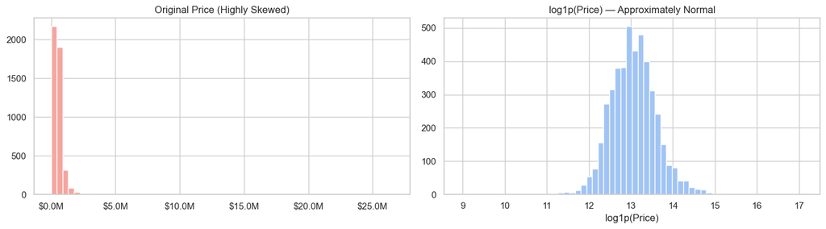

```
Skewness — original: 25.015  |  log-transformed: 0.328
```

```python
# Log-transform price
data['log_price'] = np.log1p(data['price'])

fig, axes = plt.subplots(1, 2, figsize=(14, 4))
axes[0].hist(data['price'], bins=60, color='#F4A5A0', edgecolor='white')
axes[0].set_title('Original Price (Highly Skewed)', fontsize=12)
axes[0].xaxis.set_major_formatter(mtick.FuncFormatter(lambda x, _: f'${x/1e6:.1f}M'))
axes[1].hist(data['log_price'], bins=60, color='#A0C4F4', edgecolor='white')
axes[1].set_title('log1p(Price) — Approximately Normal', fontsize=12)
axes[1].set_xlabel('log1p(Price)')
plt.tight_layout(); plt.show()

print(f"Skewness — original: {data['price'].skew():.3f}  |  log-transformed: {data['log_price'].skew():.3f}")
```

The log transformation successfully reduces right skew from 25 to near 0, and variance becomes more homogeneous across price ranges. This satisfies OLS assumptions of normality and homoscedasticity.

## 4. Exploratory Data Analysis

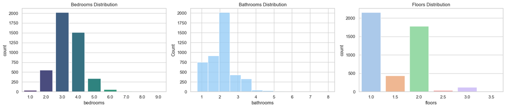

```python
# Univariate: Core structural features
fig, axes = plt.subplots(1, 3, figsize=(18, 4))
sns.countplot(data=data, x='bedrooms',  ax=axes[0], palette='viridis')
axes[0].set_title('Bedrooms Distribution')
sns.histplot(data=data, x='bathrooms', bins=12, ax=axes[1], color='#91CAF6')
axes[1].set_title('Bathrooms Distribution')
sns.countplot(data=data, x='floors', ax=axes[2], palette='pastel')
axes[2].set_title('Floors Distribution')
plt.tight_layout(); plt.show()
```

Most houses have 3–4 bedrooms, 1–3 bathrooms, and 1–2 floors (a typical residential distribution).

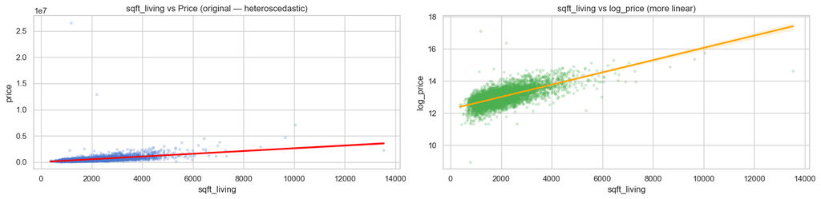

```python
# Bivariate: sqft_living vs price (original vs log)
fig, axes = plt.subplots(1, 2, figsize=(16, 4))
sns.regplot(data=data, x='sqft_living', y='price', ax=axes[0],
            scatter_kws={'alpha': 0.2, 's': 10}, line_kws={'color': 'red'})
axes[0].set_title('sqft_living vs Price (original — heteroscedastic)')
sns.regplot(data=data, x='sqft_living', y='log_price', ax=axes[1],
            scatter_kws={'alpha': 0.2, 's': 10, 'color': '#4CAF50'}, line_kws={'color': 'orange'})
axes[1].set_title('sqft_living vs log_price (more linear)')
plt.tight_layout(); plt.show()
```

The log transformation of price successfully stabilized the variance and clarified the linear relationship with `sqft_living`. This validated the choice of transformation for the regression.

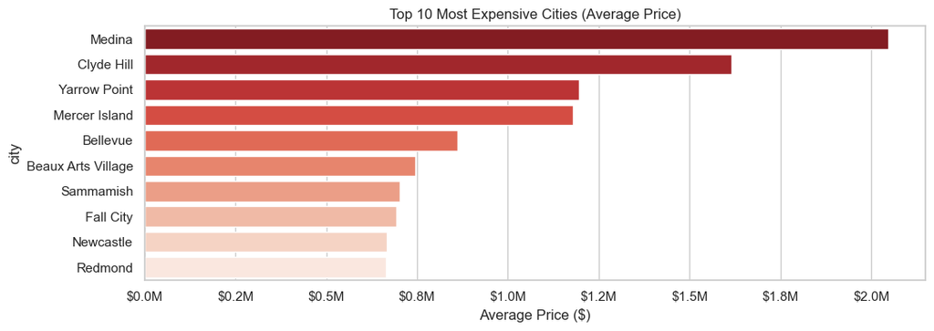

```python
# Geographic price variation
top10 = data.groupby('city')['price'].mean().sort_values(ascending=False).head(10)
plt.figure(figsize=(11, 4))
sns.barplot(x=top10.values, y=top10.index, palette='Reds_r')
plt.title('Top 10 Most Expensive Cities (Average Price)', fontsize=12)
plt.xlabel('Average Price ($)')
plt.gca().xaxis.set_major_formatter(mtick.FuncFormatter(lambda x, _: f'${x/1e6:.1f}M'))
plt.tight_layout(); plt.show()
```

Cities like Medina, Clyde Hill show dramatically higher average prices, geographic location is clearly a dominant signal. This motivates our spatial feature engineering in Section 6.

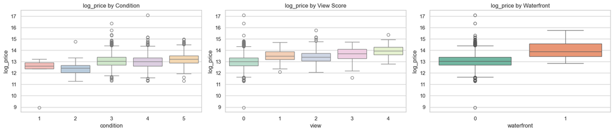

```python
# Quality ordinals vs log_price
fig, axes = plt.subplots(1, 3, figsize=(18, 4))
sns.boxplot(data=data, x='condition', y='log_price', ax=axes[0], palette='Pastel1')
axes[0].set_title('log_price by Condition')
sns.boxplot(data=data, x='view', y='log_price', ax=axes[1], palette='Pastel2')
axes[1].set_title('log_price by View Score')
sns.boxplot(data=data, x='waterfront', y='log_price', ax=axes[2], palette='Set2')
axes[2].set_title('log_price by Waterfront')
plt.tight_layout(); plt.show()
```

`View` and `waterfront` features proved to be strong predictors of price, while `condition` had a weaker but still relevant influence.

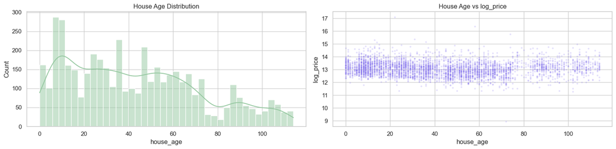

```python
# House age distribution & relationship with price
fig, axes = plt.subplots(1, 2, figsize=(16, 4))
sns.histplot(data=data, x='house_age', bins=40, kde=True, ax=axes[0], color='#95C8A0')
axes[0].set_title('House Age Distribution')
sns.scatterplot(data=data, x='house_age', y='log_price', ax=axes[1],
                alpha=0.2, s=10, color='#7B68EE')
axes[1].set_title('House Age vs log_price')
plt.tight_layout(); plt.show()
```

House age follows a bimodal distribution (many new homes and many older homes). The scatter against `log_price` shows a weak non-linear relationship — very new and very old homes can both fetch high prices, motivating the `is_new` and `is_historic` binary flags we create later.

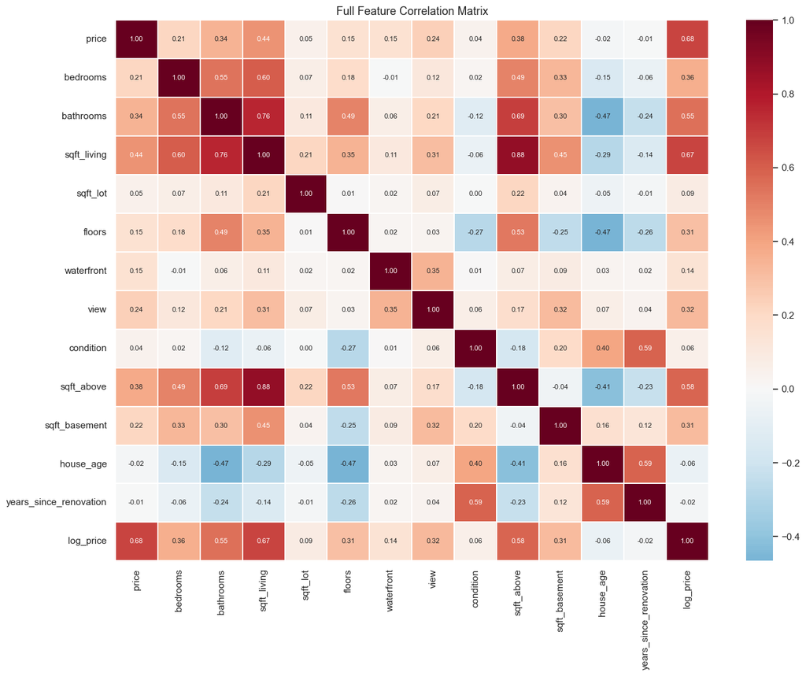

```
Top features correlated with log_price:
price           0.6772
sqft_living     0.6711
sqft_above      0.5815
bathrooms       0.5525
bedrooms        0.3595
view            0.3236
sqft_basement   0.3132
floors          0.3061
waterfront      0.1420
sqft_lot        0.0856
house_age       0.0597
condition       0.0594
```

```python
# Full correlation heatmap
numeric_cols = data.select_dtypes(include=[np.number]).columns.tolist()
corr = data[numeric_cols].corr()
plt.figure(figsize=(14, 11))
sns.heatmap(corr, annot=True, cmap='RdBu_r', center=0, fmt='.2f',
            linewidths=0.3, annot_kws={'size': 8})
plt.title('Full Feature Correlation Matrix', fontsize=13)
plt.tight_layout(); plt.show()

# Top correlations with log_price
print("\nTop features correlated with log_price:")
print(corr['log_price'].drop('log_price').abs().sort_values(ascending=False).head(12).to_string())
```

Based on the correlation matrix with **log_price**, we observe:

- **Size matters most:**  
  `sqft_living (0.6711)` and `sqft_above (0.5815)` show the strongest positive correlations with price.
- **Amenities contribute moderately:**  
  `bathrooms (0.5525)` and `bedrooms (0.3595)` are meaningful predictors of housing price.

## 5. Train/Test Split

```python
city_raw    = data['city'].astype(str).copy()
zipcode_raw = data['zipcode'].astype(str).copy()
log_price_all = data['log_price'].copy()

# Label-encode for baseline model
le = LabelEncoder()
data_ml = data.copy()
data_ml['city']    = le.fit_transform(data_ml['city'].astype(str))
data_ml['zipcode'] = le.fit_transform(data_ml['zipcode'].astype(str))

X_base = data_ml.drop(columns=['price', 'log_price'])
y      = data_ml['log_price']

# Split into train/test sets (80/20) with fixed random state for reproducibility
X_tr_base, X_te_base, y_train, y_test = train_test_split(
    X_base, y, test_size=0.2, random_state=42)

train_idx = X_tr_base.index.tolist()
test_idx  = X_te_base.index.tolist()

print(f"Train: {len(train_idx):,} rows  |  Test: {len(test_idx):,} rows")
```

```
Train: 3,629 rows  |  Test: 908 rows
```

80/20 random split with `random_state=42` for reproducibility. City and zipcode are label-encoded here for the baseline OLS only; target encoding is applied separately in the full feature engineering pipeline.

## 6. Feature Engineering

| Category | Features |
| --- | --- |
| A. Baseline Structural | 12 |
| B. Non-Linear Basis | 8 |
| C. Domain-Informed Metrics | 7 |
| D. Categorical & Binary | 7 |
| E. Interaction Effects | 7 |
| F. Spatial / Geographic | 4 |

```python
# KFold Target Encoding
def kfold_target_encode(series_all, target_all, train_idx, test_idx,
                        n_splits=5, random_state=42):

    encoded = np.zeros(len(series_all))
    s_all = series_all.reset_index(drop=True)
    t_all = target_all.reset_index(drop=True)

    s_train = s_all.iloc[train_idx].reset_index(drop=True)
    t_train = t_all.iloc[train_idx].reset_index(drop=True)
    global_mean = t_train.mean()

    kf = KFold(n_splits=n_splits, shuffle=True, random_state=random_state)
    fold_enc = np.full(len(s_train), np.nan)

    for tr_rel, va_rel in kf.split(s_train):
        means = t_train.iloc[tr_rel].groupby(s_train.iloc[tr_rel]).mean()
        fold_enc[va_rel] = s_train.iloc[va_rel].map(means).fillna(global_mean).values

    for i, idx in enumerate(train_idx):
        encoded[idx] = fold_enc[i]

    full_means = t_train.groupby(s_train).mean()
    for idx in test_idx:
        encoded[idx] = full_means.get(s_all.iloc[idx], global_mean)

    return encoded

print("kfold_target_encode() defined.")
```

```
kfold_target_encode() defined.
```

KFold target encoding computes the mean target per category using out-of-fold data only, preventing target leakage. Test rows are encoded using means computed on the full training set.

```python
# Feature Engineering Pipeline
df = data.copy()
log_price_all = df['log_price'].copy()

# A. Baseline Structural (12)
# bedrooms, bathrooms, sqft_living, sqft_lot, floors,
# waterfront, view, condition, sqft_above, sqft_basement,
# house_age, years_since_renovation  — already in df

# B. Non-Linear Basis Expansion (8)
df['sqft_living_sq']   = df['sqft_living'] ** 2
df['sqft_living_sqrt'] = np.sqrt(df['sqft_living'])
df['sqft_living_log']  = np.log1p(df['sqft_living'])
df['sqft_lot_log']     = np.log1p(df['sqft_lot'])
df['sqft_above_log']   = np.log1p(df['sqft_above'])
df['sqft_bsmt_log']    = np.log1p(df['sqft_basement'])
df['bath_per_bed']     = df['bathrooms'] / (df['bedrooms'] + 0.1)
df['bed_bath_sum']     = df['bedrooms'] + df['bathrooms']

# C. Domain-Informed Structural Metrics (7)
df['lot_utilization']  = df['sqft_living']  / (df['sqft_lot'] + 1)
df['avg_room_size']    = df['sqft_living']  / (df['bed_bath_sum'] + 0.1)
df['has_basement']     = (df['sqft_basement'] > 0).astype(int)
df['above_grade_frac'] = df['sqft_above']   / (df['sqft_living'] + 1)
df['basement_frac']    = df['sqft_basement'] / (df['sqft_living'] + 1)
df['effective_living'] = df['sqft_above'] + 0.5 * df['sqft_basement']
df['sqft_per_room'] = df['sqft_living'] / (df['bedrooms'] * df['bathrooms'] + 1)

# D. Categorical & Binary Indicators (7)
df['is_luxury']        = ((df['view'] >= 3) & (df['condition'] >= 4)).astype(int)
df['is_renovated']     = (df['years_since_renovation'] < df['house_age']).astype(int)
df['is_historic']      = (df['house_age'] > 75).astype(int)
df['is_new']           = (df['house_age'] <= 5).astype(int)
df['age_category']     = pd.cut(df['house_age'],
                                bins=[-1, 5, 20, 50, 75, 999],
                                labels=[0, 1, 2, 3, 4]).astype(int)
df['waterfront_view']  = df['waterfront'] * df['view']
df['condition_view']   = df['condition'] * df['view']

# E. Interaction Effects (7)
df['living_x_cond']    = df['sqft_living'] * df['condition']
df['living_x_view']    = df['sqft_living'] * df['view']
df['living_x_wf']      = df['sqft_living'] * df['waterfront']
df['log_living_x_cond']= df['sqft_living_log'] * df['condition']
df['log_living_x_view']= df['sqft_living_log'] * df['view']
df['age_x_cond']       = df['house_age'] * df['condition']
df['bed_x_sqft']       = df['bedrooms'] * df['sqft_living_log']

print(f"Current df shape: {df.shape}")
```

```
Current df shape: (4537, 45)
```

**Categories A–E** add polynomial transformations, domain ratios (e.g. `bath_per_bed`, `lot_utilization`), interaction terms, and binary flags.

```python
# F. Spatial & Geographic Features (4)

city_series    = city_raw.copy()
zipcode_series = zipcode_raw.copy()

# F1. City-level price signal (KFold target encoding)
df['city_price_signal'] = kfold_target_encode(
    city_series, log_price_all, train_idx, test_idx)

# F2. Zipcode-level price signal
df['zipcode_price_signal'] = kfold_target_encode(
    zipcode_series, log_price_all, train_idx, test_idx)

# F3. KNN Neighbor Price Proxy
# Train rows: each row's proxy is predicted from other training folds
# Test rows : proxy predicted by KNN fitted on full training set
knn_loc_cols  = ['city_price_signal', 'zipcode_price_signal']
knn_proxy     = np.zeros(len(df))

train_arr     = df.iloc[train_idx][knn_loc_cols].values
y_train_arr   = log_price_all.iloc[train_idx].values

kf_knn = KFold(n_splits=5, shuffle=True, random_state=42)
for tr_rel, va_rel in kf_knn.split(train_arr):
    sc  = RobustScaler()
    knn = KNeighborsRegressor(n_neighbors=10, metric='euclidean', weights='distance')
    knn.fit(sc.fit_transform(train_arr[tr_rel]), y_train_arr[tr_rel])
    knn_proxy[np.array(train_idx)[va_rel]] = knn.predict(sc.transform(train_arr[va_rel]))

sc_f   = RobustScaler()
knn_f  = KNeighborsRegressor(n_neighbors=10, metric='euclidean', weights='distance')
knn_f.fit(sc_f.fit_transform(train_arr), y_train_arr)
knn_proxy[test_idx] = knn_f.predict(sc_f.transform(df.iloc[test_idx][knn_loc_cols].values))

df['neighbor_price_proxy'] = knn_proxy

# F4. KMeans Cluster Label
km_feat_cols = ['city_price_signal', 'zipcode_price_signal', 'sqft_living', 'sqft_lot']
km_feat = df[km_feat_cols].copy()

sc_km = RobustScaler()
km_train_scaled = sc_km.fit_transform(km_feat.iloc[train_idx])
kmeans = KMeans(n_clusters=12, random_state=42, n_init=10)
kmeans.fit(km_train_scaled)

df['cluster_label'] = kmeans.predict(sc_km.transform(km_feat))

# verification assessment
corr_proxy = np.corrcoef(
    df.iloc[train_idx]['neighbor_price_proxy'].values,
    log_price_all.iloc[train_idx].values
)[0, 1]
print(f"neighbor_price_proxy - train target correlation: {corr_proxy:.4f}")
print(f"  (deliberate appraisal-style feature; KFold prevents leakage)")
```

```
neighbor_price_proxy - train target correlation: 0.6931
  (deliberate appraisal-style feature; KFold prevents leakage)
```

**KNN neighbor price proxy**: for each house, the predicted price from its 10 nearest geographic neighbors (by city/zip signal) is used as a spatial appraisal signal. **KMeans cluster label** groups properties into 12 price-based geographic zones.

The feature `neighbor_price_proxy` shows a strong correlation with the target (~0.69), indicating high predictive relevance consistent with an appraisal-based spatial effect. Despite its strength, the feature is not considered to introduce leakage due to its construction using KFold encoding, which ensures that target information from the same samples is not directly used during feature generation. Therefore, it remains a valid and informative feature for modeling.

```python
# Truncated Power Spline Basis

sqft_train = df.iloc[train_idx]['sqft_living'].values
knot_pcts  = [10, 25, 40, 55, 70, 85]
inner_knots= np.percentile(sqft_train, knot_pcts)

def truncated_power_basis(x, knots, degree=3):
    cols = [x**d for d in range(degree + 1)]     # 1, x, x², x³
    for k in knots:
        cols.append(np.maximum(x - k, 0) ** degree)
    return np.column_stack(cols)

spline_mat = truncated_power_basis(df['sqft_living'].values, inner_knots)
spline_cols = [f'spline_{i}' for i in range(spline_mat.shape[1])]
for i, col in enumerate(spline_cols):
    df[col] = spline_mat[:, i]

print(f"Spline basis: {len(spline_cols)} columns")
print(f"Knots at sqft_living percentiles {knot_pcts}: {inner_knots.astype(int).tolist()}")
print(f"\nTotal df columns: {df.shape[1]}")
```

```
Spline basis: 10 columns
Knots at sqft_living percentiles [10, 25, 40, 55, 70, 85]: [1100, 1460, 1770, 2070, 2470, 3010]

Total df columns: 59
```

Truncated power spline basis on `sqft_living` adds 10 basis columns that allow the model to fit smooth, flexible non-linear curves between size and price — without requiring a tree-based model. Note: this uses a truncated power basis, not a natural cubic spline; boundary behaviour remains cubic rather than linear beyond the outermost knots.

```python
# Natural Cubic Spline Basis (patsy cr())
from patsy import dmatrix

ncs_train = dmatrix("cr(sqft_living, df=8) - 1",
                    {"sqft_living": df.iloc[train_idx]['sqft_living'].values},
                    return_type='dataframe')

ncs_full = dmatrix(ncs_train.design_info,
                   {"sqft_living": df['sqft_living'].values},
                   return_type='dataframe')

ncs_cols = [f'ncs_{i}' for i in range(ncs_full.shape[1])]
for i, col in enumerate(ncs_cols):
    df[col] = ncs_full.iloc[:, i].values

print(f"NCS basis: {len(ncs_cols)} columns (df=8)")
```

```
NCS basis: 8 columns (df=8)
```

Natural Cubic Spline basis using `patsy cr()` with df=8 (6 inner knots). Unlike the truncated power basis above, NCS enforces linear boundary conditions beyond the outermost knots, giving better extrapolation behaviour. Knot positions are fitted on the training set only; the same design is applied to test via `design_info` to prevent leakage.

```python
# Encode city/zipcode as integers for tree model
df['city']    = le.fit_transform(df['city'].astype(str))
df['zipcode'] = le.fit_transform(df['zipcode'].astype(str))

# Define feature sets
core_features = [
    # Baseline (12)
    'bedrooms', 'bathrooms', 'sqft_living', 'sqft_lot', 'floors',
    'waterfront', 'view', 'condition', 'sqft_above', 'sqft_basement',
    'house_age', 'years_since_renovation',
    # Non-linear (8)
    'sqft_living_sq', 'sqft_living_sqrt', 'sqft_living_log',
    'sqft_lot_log', 'sqft_above_log', 'sqft_bsmt_log',
    'bath_per_bed', 'bed_bath_sum',
    # Domain (7)
    'lot_utilization', 'avg_room_size', 'has_basement',
    'above_grade_frac', 'basement_frac', 'effective_living', 'sqft_per_room',
    # Categorical (7)
    'is_luxury', 'is_renovated', 'is_historic', 'is_new',
    'age_category', 'waterfront_view', 'condition_view',
    # Interactions (7)
    'living_x_cond', 'living_x_view', 'living_x_wf',
    'log_living_x_cond', 'log_living_x_view', 'age_x_cond', 'bed_x_sqft',
    # Spatial (4)
    'city_price_signal', 'zipcode_price_signal',
    'neighbor_price_proxy', 'cluster_label',
]

extended_features = core_features + spline_cols  # adds 10 spline cols

X_train = df.loc[train_idx, core_features].copy()
X_test  = df.loc[test_idx,  core_features].copy()

print(f"CORE features    : {len(core_features)}")
print(f"EXTENDED features: {len(extended_features)}")
print(f"X_train: {X_train.shape}  |  X_test: {X_test.shape}")
```

```
CORE features    : 45
EXTENDED features: 55
X_train: (3629, 45)  |  X_test: (908, 45)
```

Two feature sets are defined: **core** (45 features, no splines) used for all linear and regularised models; **extended** (45 + 10 truncated power spline columns) used for Spline+Lasso and Spline+ElasticNet models; and **ncs** (45 + 8 NCS columns) used for the NCS+ElasticNet model in Section 12.

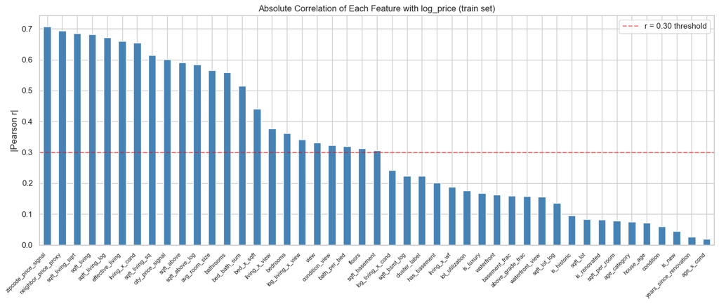

```
Top 10 features by correlation with log_price:
zipcode_price_signal   0.7066
neighbor_price_proxy   0.6931
sqft_living_sqrt       0.6847
sqft_living            0.6815
sqft_living_log        0.6715
effective_living       0.6601
living_x_cond          0.6556
sqft_living_sq         0.6147
city_price_signal      0.6016
sqft_above             0.5914
```

```python
# Feature correlation with log_price
feat_corr = {}
for col in core_features:
    feat_corr[col] = abs(np.corrcoef(df.loc[train_idx, col], log_price_all.iloc[train_idx])[0, 1])

corr_series = pd.Series(feat_corr).sort_values(ascending=False)
plt.figure(figsize=(14, 6))
corr_series.plot(kind='bar', color='steelblue', edgecolor='white')
plt.axhline(0.3, color='red', linestyle='--', alpha=0.5, label='r = 0.30 threshold')
plt.title('Absolute Correlation of Each Feature with log_price (train set)', fontsize=12)
plt.ylabel('|Pearson r|')
plt.xticks(rotation=45, ha='right', fontsize=8)
plt.legend()
plt.tight_layout(); plt.show()

print(f"\nTop 10 features by correlation with log_price:")
print(corr_series.head(10).to_string())
```

The chart highlights the top predictors for log_price, leading to the following observations:

- Spatial Dominance: Location-based signals—specifically zipcode_price_signal (0.71) and neighbor_price_proxy (0.69)—show the strongest correlation with property value.
- Structural Size: Features related to living area, such as sqft_living and its transformations, remain primary drivers of price.

## 7. Baseline OLS

```python
# Evaluation function
def mape(y_true_log, y_pred_log):
    return float(np.mean(np.abs(
        (np.expm1(y_true_log) - np.expm1(y_pred_log)) / np.expm1(y_true_log)
    )) * 100)

mape_scorer = make_scorer(mape, greater_is_better=False)
KF = KFold(n_splits=5, shuffle=True, random_state=42)
results = {}

def evaluate(model, X_tr, y_tr, X_te, y_te, label, focus=''):
    model.fit(X_tr, y_tr)
    y_pred    = model.predict(X_te)
    y_pred_tr = model.predict(X_tr)
    t_mape    = mape(y_te, y_pred)
    tr_mape   = mape(y_tr, y_pred_tr)
    t_r2      = r2_score(y_te, y_pred)
    cv_raw    = cross_val_score(model, X_tr, y_tr, cv=KF,
                                scoring=mape_scorer, n_jobs=-1)
    cv_m, cv_s = float(-cv_raw.mean()), float(cv_raw.std())
    print(f"[{label}]  Train MAPE: {tr_mape:.2f}%  Test MAPE: {t_mape:.2f}%  R²: {t_r2:.4f}  |  CV MAPE: {cv_m:.2f}% ± {cv_s:.2f}%")
    return dict(label=label, model=model, train_mape=tr_mape, test_mape=t_mape, test_r2=t_r2,
                cv_mape=cv_m, cv_mape_std=cv_s, y_pred=y_pred, focus=focus)

print("evaluation function defined.")
```

```
evaluation function defined.
```

```python
# Baseline OLS — no feature engineering, label-encoded city/zipcode
results['00_Baseline'] = evaluate(
    LinearRegression(),
    X_tr_base, y_train, X_te_base, y_test,
    '00. Baseline OLS', 'Raw data only (label encoded)'
)
```

```
[00. Baseline OLS]  Train MAPE: 30.40%  Test MAPE: 30.59%  R²: 0.4796  |  CV MAPE: 30.59% ± 1.80%
```

The baseline OLS — using raw features with label-encoded city/zip — defines our performance floor for evaluating feature engineering improvements. However, because label encoding imposes an artificial ordinal structure on locations, the model misinterprets these values and fails to capture key price signals, resulting in high MAPE.

## 8. Iterative OLS — Feature Engineering Stages

```python
# 1: Polynomial + basic interactions
S1 = ['bedrooms','bathrooms','sqft_living','sqft_lot','floors',
      'waterfront','view','condition','sqft_above','sqft_basement',
      'house_age','years_since_renovation',
      'sqft_living_sq','sqft_living_log','sqft_lot_log','bath_per_bed',
      'living_x_cond','is_luxury']
results['01_Poly'] = evaluate(
    LinearRegression(), X_train[S1], y_train, X_test[S1], y_test,
    '01. OLS + Polynomial/Interaction', 'Poly terms + interactions')
```

```
[01. OLS + Polynomial/Interaction]  Train MAPE: 30.48%  Test MAPE: 28.67%  R²: 0.5112  |  CV MAPE: 30.72% ± 1.32%
```

**Stage 1 - OLS + Polynomial & Interaction Terms** introduces polynomial and interaction terms on top of the baseline, resulting in only a modest improvement. While features such as `sqft_living²`, `bath_per_bed`, and `living × condition` add some nonlinearity, their impact remains limited. This highlights that structural attributes alone (e.g., size, number of rooms, condition) are not sufficient to explain price variation. Without any representation of location, the model still lacks critical spatial context. As a result, increasing feature complexity through polynomial terms cannot compensate for the missing location signal, leading to only marginal performance gains.

```python
# 2: + Location signals (target encoding)
S2 = S1 + ['city_price_signal','zipcode_price_signal','age_category']
results['02_Location'] = evaluate(
    LinearRegression(), X_train[S2], y_train, X_test[S2], y_test,
    '02. OLS + Location Signals', 'KFold target encoding city/zip')
```

```
[02. OLS + Location Signals]  Train MAPE: 18.44%  Test MAPE: 18.93%  R²: 0.6862  |  CV MAPE: 18.70% ± 1.25%
```

**Stage 2 — OLS + Location Signals** introduces KFold target-encoded city and zip, delivering the largest MAPE drop in the entire experiment. This confirms that location is the dominant price driver. Unlike naive label encoding (Stage 0), which imposed false ordinal relationships and degraded performance, target encoding captures meaningful location signals.

```python
# 3: + Domain ratios & indicators
S3 = S2 + ['lot_utilization','avg_room_size','has_basement','is_renovated',
            'is_historic','above_grade_frac','effective_living',
            'basement_frac','waterfront_view','condition_view']
results['03_Domain'] = evaluate(
    LinearRegression(), X_train[S3], y_train, X_test[S3], y_test,
    '03. OLS + Domain Ratios', 'Domain metrics + binary indicators')
```

```
[03. OLS + Domain Ratios]  Train MAPE: 18.23%  Test MAPE: 18.91%  R²: 0.6881  |  CV MAPE: 18.60% ± 1.31%
```

```python
# 4: + KNN spatial + KMeans + extended interactions
S4 = S3 + ['neighbor_price_proxy','cluster_label',
            'sqft_living_sqrt','sqft_above_log','sqft_bsmt_log',
            'living_x_view','living_x_wf','log_living_x_cond',
            'log_living_x_view','age_x_cond','bed_x_sqft',
            'is_new','bed_bath_sum','sqft_per_room']
results['04_Spatial'] = evaluate(
    LinearRegression(), X_train[S4], y_train, X_test[S4], y_test,
    '04. OLS + KNN Spatial + Extended', 'KNN proxy + KMeans + all interactions')
```

```
[04. OLS + KNN Spatial + Extended]  Train MAPE: 17.65%  Test MAPE: 18.23%  R²: 0.6955  |  CV MAPE: 18.12% ± 0.99%
```

**Stage 4 — OLS + Spatial Proxy & Clusters** incorporates a KNN-based neighbor price proxy and KMeans cluster labels, delivering a solid improvement. The spatial proxy adds meaningful signal by capturing local price patterns, while the cluster label contributes limited standalone value and mainly serves as contextual grouping. Its ordinal encoding (0–11) also limits its effectiveness.

```python
# 5: Full core feature set
results['05_Full_OLS'] = evaluate(
    LinearRegression(), X_train[core_features], y_train, X_test[core_features], y_test,
    '05. OLS Full Core (45 features)', 'All 45 core features')
```

```
[05. OLS Full Core (45 features)]  Train MAPE: 17.65%  Test MAPE: 18.23%  R²: 0.6955  |  CV MAPE: 18.12% ± 0.99%
```

**Stage 5 — Full OLS (45 Features)** produces identical results to Stage 4, confirming that the additional features introduced in Stage 4 already cover the full core feature set. Without regularisation, OLS remains susceptible to overfitting as features increase, motivating the transition to regularized models in the next section.

## 9. Regularized Models

```python
# Ridge with alpha tuning
alphas_ridge = [0.01, 0.1, 0.5, 1.0, 5.0, 10.0, 50.0, 100.0]
gs_ridge = GridSearchCV(
    Pipeline([('sc', RobustScaler()), ('m', Ridge())]),
    {'m__alpha': alphas_ridge}, cv=KF, scoring=mape_scorer, n_jobs=-1
)
gs_ridge.fit(X_train[core_features], y_train)
print(f"Best Ridge alpha: {gs_ridge.best_params_}")
results['06_Ridge'] = evaluate(
    gs_ridge.best_estimator_, X_train[core_features], y_train, X_test[core_features], y_test,
    '06. Ridge (L2 tuned)', 'L2 regularisation, tuned alpha')
```

```
Best Ridge alpha: {'m__alpha': 1.0}
[06. Ridge (L2 tuned)]  Train MAPE: 17.68%  Test MAPE: 18.26%  R²: 0.6948  |  CV MAPE: 18.06% ± 1.03%
```

**Ridge (L2, tuned α)** shrinks coefficients to reduce overfitting, producing stable generalisation comparable to full OLS. However, it retains all 45 features, including weak ones, limiting interpretability. Ridge also struggles slightly with highly collinear features (e.g., polynomial size terms), where ElasticNet's combined L1+L2 penalty provides marginally more stable estimates.

```python
# Lasso with alpha tuning
alphas_lasso = [0.00005, 0.0001, 0.0005, 0.001, 0.005, 0.01, 0.05]
gs_lasso = GridSearchCV(
    Pipeline([('sc', RobustScaler()), ('m', Lasso(max_iter=10000))]),
    {'m__alpha': alphas_lasso}, cv=KF, scoring=mape_scorer, n_jobs=-1
)
gs_lasso.fit(X_train[core_features], y_train)
print(f"Best Lasso alpha: {gs_lasso.best_params_}")
results['07_Lasso'] = evaluate(
    gs_lasso.best_estimator_, X_train[core_features], y_train, X_test[core_features], y_test,
    '07. Lasso (L1 tuned)', 'L1 feature selection, tuned alpha')
```

```
Best Lasso alpha: {'m__alpha': 0.0001}
[07. Lasso (L1 tuned)]  Train MAPE: 17.71%  Test MAPE: 18.24%  R²: 0.6951  |  CV MAPE: 18.07% ± 1.04%
```

**Lasso (L1, tuned α)** performs automatic feature selection by shrinking some coefficients to zero, improving interpretability. However, performance gains are limited, and in the presence of correlated features, Lasso can be unstable—arbitrarily selecting one while discarding others—making results sensitive to data variation. This motivates the use of ElasticNet for greater stability.

```python
# ElasticNet with grid search
param_en = {
    'm__alpha'   : [0.00005, 0.0001, 0.0005, 0.001, 0.005, 0.01],
    'm__l1_ratio': [0.1, 0.2, 0.3, 0.5, 0.7, 0.8, 0.9],
}
gs_en = GridSearchCV(
    Pipeline([('sc', RobustScaler()), ('m', ElasticNet(max_iter=10000))]),
    param_en, cv=KF, scoring=mape_scorer, n_jobs=-1, verbose=0
)
gs_en.fit(X_train[core_features], y_train)
best_en_params = gs_en.best_params_
print(f"Best ElasticNet: {best_en_params}")
results['08_ElasticNet'] = evaluate(
    gs_en.best_estimator_, X_train[core_features], y_train, X_test[core_features], y_test,
    '08. ElasticNet (tuned)', 'L1+L2, grid-searched alpha & l1_ratio')
```

```
Best ElasticNet: {'m__alpha': 0.0005, 'm__l1_ratio': 0.1}
[08. ElasticNet (tuned)]  Train MAPE: 17.70%  Test MAPE: 18.25%  R²: 0.6951  |  CV MAPE: 18.07% ± 1.05%
```

```python
# Huber Regressor with grid search
param_huber = {'m__epsilon': [1.1, 1.2, 1.35, 1.5, 1.75, 2.0],
               'm__alpha'  : [0.0001, 0.001, 0.01]}
gs_huber = GridSearchCV(
    Pipeline([('sc', RobustScaler()), ('m', HuberRegressor(max_iter=5000))]),
    param_huber, cv=KF, scoring=mape_scorer, n_jobs=-1
)
gs_huber.fit(X_train[core_features], y_train)
print(f"Best Huber params: {gs_huber.best_params_}")
results['09_Huber'] = evaluate(
    gs_huber.best_estimator_, X_train[core_features], y_train, X_test[core_features], y_test,
    '09. Huber (tuned)', 'Robust to outliers, tuned epsilon')
```

```
Best Huber params: {'m__alpha': 0.0001, 'm__epsilon': 2.0}
[09. Huber (tuned)]  Train MAPE: 19.36%  Test MAPE: 19.44%  R²: 0.5746  |  CV MAPE: 19.69% ± 0.72%
```

**Huber Regressor (tuned α & ε)** applies a robust loss that is quadratic for small errors and linear for large ones, making it less sensitive to outliers. However, it underperforms all other regularised models in this setting. This is likely because the log-transformation of price already reduces the influence of extreme values, diminishing Huber's robustness advantage. As a result, Huber increases computational cost (slower convergence) without meaningful MAPE improvement.

```python
# Bayesian Ridge
results['10_BayesianRidge'] = evaluate(
    Pipeline([('sc', RobustScaler()), ('m', BayesianRidge(max_iter=500))]),
    X_train[core_features], y_train, X_test[core_features], y_test,
    '10. Bayesian Ridge', 'Automatic regularisation via marginal likelihood')
```

```
[10. Bayesian Ridge]  Train MAPE: 17.72%  Test MAPE: 18.23%  R²: 0.6957  |  CV MAPE: 18.08% ± 1.07%
```

**Bayesian Ridge** infers optimal regularisation strength via marginal likelihood, removing the need for manual tuning. However, in this experiment it achieves only marginal performance, converging to results similar to tuned Ridge without meaningful MAPE improvement. While it offers the additional benefit of posterior uncertainty estimates, this advantage is not utilised here since evaluation is based on point predictions. Overall, it is not preferred over tuned Ridge or ElasticNet for pure MAPE optimisation.

## 10. Advanced Linear Models

- **Ridge + Polynomial features** (degree-2 PolynomialFeatures on top spatial features)
- **Quantile Regression** (predict median instead of mean — robust to skew)
- **Feature-selected ElasticNet** (RFECV to remove weak features)
- **PCA-compressed Ridge** (dimensionality reduction before Ridge)

```python
# Ridge + Polynomial Features (degree=2 on selected features)
class PolySubsetRidge:
    def __init__(self, poly_cols, remaining_cols, degree=2, alpha=10.0):
        self.poly_cols = poly_cols
        self.remaining_cols = remaining_cols

        self.poly = PolynomialFeatures(degree=degree, include_bias=False)
        self.sc_poly = RobustScaler()
        self.sc_rest = RobustScaler()
        self.model = Ridge(alpha=alpha)

    def fit(self, X, y):
        Xp = self.sc_poly.fit_transform(X[self.poly_cols].values)
        Xp = self.poly.fit_transform(Xp)

        Xr = self.sc_rest.fit_transform(X[self.remaining_cols].values)

        Xc = np.hstack([Xp, Xr])

        self.model.fit(Xc, y)
        return self

    def predict(self, X):
        Xp = self.sc_poly.transform(X[self.poly_cols].values)
        Xp = self.poly.transform(Xp)

        Xr = self.sc_rest.transform(X[self.remaining_cols].values)

        return self.model.predict(np.hstack([Xp, Xr]))


poly_cols = ['sqft_living_log', 'city_price_signal', 'zipcode_price_signal',
             'neighbor_price_proxy', 'condition', 'view', 'house_age']
remaining_core = [col for col in core_features if col not in poly_cols]

# Tune alpha
best_poly_alpha, best_poly_mape = 10.0, np.inf
for alpha in [1.0, 5.0, 10.0, 50.0, 100.0]:
    cv_m = []
    for tr_r, va_r in KF.split(X_train):
        m = PolySubsetRidge(poly_cols, remaining_core, degree=2, alpha=alpha)
        m.fit(X_train.iloc[tr_r], y_train.iloc[tr_r])
        cv_m.append(mape(y_train.iloc[va_r], m.predict(X_train.iloc[va_r])))
    if np.mean(cv_m) < best_poly_mape:
        best_poly_mape = np.mean(cv_m)
        best_poly_alpha = alpha

poly_model = PolySubsetRidge(
    poly_cols=poly_cols,
    remaining_cols=remaining_core,
    degree=2,
    alpha=best_poly_alpha
)

poly_model.fit(X_train, y_train)

y_pred_train = poly_model.predict(X_train)
y_pred_test  = poly_model.predict(X_test)

poly_train_mape = mape(y_train, y_pred_train)
poly_test_mape  = mape(y_test, y_pred_test)
poly_r2         = r2_score(y_test, y_pred_test)

cv_poly = []

X_tr = X_train.reset_index(drop=True)
y_tr = y_train.reset_index(drop=True)

for tr_idx, va_idx in KF.split(X_tr):

    m = PolySubsetRidge(
        poly_cols=poly_cols,
        remaining_cols=remaining_core,
        degree=2,
        alpha=best_poly_alpha
    )

    m.fit(X_tr.iloc[tr_idx], y_tr.iloc[tr_idx])
    pred_va = m.predict(X_tr.iloc[va_idx])

    cv_poly.append(mape(y_tr.iloc[va_idx], pred_va))

cv_poly_mean = np.mean(cv_poly)
cv_poly_std  = np.std(cv_poly)

results['11_PolyRidge'] = dict(
    model=poly_model,
    label='11. Ridge Regression with Polynomial Interaction Features',
    train_mape=poly_train_mape,
    test_mape=poly_test_mape,
    test_r2=poly_r2,
    cv_mape=cv_poly_mean,
    cv_mape_std=cv_poly_std,
    focus=f'Degree-2 poly + RobustScaler + Ridge, alpha={best_poly_alpha}'
)

print(
    f"[11. PolyRidge] "
    f"Train MAPE: {poly_train_mape:.2f}% | "
    f"Test MAPE: {poly_test_mape:.2f}% | "
    f"R²: {poly_r2:.4f} | "
    f"CV MAPE: {cv_poly_mean:.2f}% ± {cv_poly_std:.2f}%"
)
```

```
[11. PolyRidge] Train MAPE: 17.31% | Test MAPE: 17.91% | R²: 0.6981 | CV MAPE: 17.90% ± 1.14%
```

This setup achieves the best performance among linear approaches, striking a balance between expressiveness and generalisation. A degree-3 expansion was also tested but led to clear overfitting due to the high-dimensional feature space, which even Ridge could not sufficiently regularise. Degree-2 therefore represents the optimal trade-off between model complexity and stability.

```python
# Quantile Regression (predict median, robust to outliers)
# Uses quantile=0.5 (median regression) -> less sensitive to luxury outliers
# Train Quantile model
sc_q = RobustScaler()
X_tr_sc_q = sc_q.fit_transform(X_train[core_features])
X_te_sc_q = sc_q.transform(X_test[core_features])

best_q_alpha, best_q_mape = 0.001, np.inf

for alpha in [0.0001, 0.001, 0.01, 0.1]:
    cv_m = []

    for tr_r, va_r in KF.split(X_tr_sc_q):
        qr = QuantileRegressor(quantile=0.5, alpha=alpha, solver='highs')
        qr.fit(X_tr_sc_q[tr_r], y_train.values[tr_r])

        pred_va = qr.predict(X_tr_sc_q[va_r])
        cv_m.append(mape(y_train.values[va_r], pred_va))

    if np.mean(cv_m) < best_q_mape:
        best_q_mape = np.mean(cv_m)
        best_q_alpha = alpha

# Fit best model
qr_best = QuantileRegressor(
    quantile=0.5,
    alpha=best_q_alpha,
    solver='highs'
)

qr_best.fit(X_tr_sc_q, y_train)

y_pred_train_qr = qr_best.predict(X_tr_sc_q)
y_pred_test_qr  = qr_best.predict(X_te_sc_q)

qr_train_mape = mape(y_train, y_pred_train_qr)
qr_test_mape  = mape(y_test, y_pred_test_qr)
qr_r2         = r2_score(y_test, y_pred_test_qr)

cv_qr = []

for tr_r, va_r in KF.split(X_tr_sc_q):
    qr = QuantileRegressor(
        quantile=0.5,
        alpha=best_q_alpha,
        solver='highs'
    )

    qr.fit(X_tr_sc_q[tr_r], y_train.values[tr_r])

    pred_va = qr.predict(X_tr_sc_q[va_r])
    cv_qr.append(mape(y_train.values[va_r], pred_va))

cv_qr_mean = np.mean(cv_qr)
cv_qr_std  = np.std(cv_qr)

results['12_Quantile'] = dict(
    label='12. Quantile Regression (median)',
    train_mape=qr_train_mape,
    test_mape=qr_test_mape,
    test_r2=qr_r2,
    cv_mape=cv_qr_mean,
    cv_mape_std=cv_qr_std,
    focus='Median regression, robust to price outliers'
)

print(f"[12. Quantile Regression] "
      f"Train MAPE: {qr_train_mape:.2f}% | "
      f"Test MAPE: {qr_test_mape:.2f}% | "
      f"R²: {qr_r2:.4f} | "
      f"CV MAPE: {cv_qr_mean:.2f}% ± {cv_qr_std:.2f}%")
```

```
[12. Quantile Regression] Train MAPE: 17.80% | Test MAPE: 18.31% | R²: 0.6961 | CV MAPE: 18.26% ± 1.06%
```

**Quantile Regression (median, tuned α)** minimises absolute error rather than squared error, making it inherently robust to outliers. However, it does not outperform standard OLS in this setting. This is because the log-transform of price already stabilises and symmetrises the target distribution, reducing the need for median-based robustness. As a result, quantile regression provides no additional MAPE benefit while being computationally slower due to its linear programming optimisation.

```python
# ElasticNet with Recursive Feature Elimination (RFECV)
sc_rfe = RobustScaler()
X_tr_sc_rfe = sc_rfe.fit_transform(X_train[core_features])
X_te_sc_rfe = sc_rfe.transform(X_test[core_features])

en_params = {k.replace('m__',''): v for k, v in best_en_params.items()}
base_en = ElasticNet(**en_params, max_iter=10000)

selector = RFECV(
    estimator=base_en,
    step=1,
    cv=KF,
    scoring=mape_scorer,
    min_features_to_select=10,
    n_jobs=-1
)

selector.fit(X_tr_sc_rfe, y_train)

selected_features = [
    core_features[i]
    for i in range(len(core_features))
    if selector.support_[i]
]

print(f"RFECV selected {len(selected_features)} / {len(core_features)} features")

en_rfe = ElasticNet(**en_params, max_iter=10000)

X_train_sel = X_tr_sc_rfe[:, selector.support_]
X_test_sel  = X_te_sc_rfe[:, selector.support_]

en_rfe.fit(X_train_sel, y_train)

y_pred_train = en_rfe.predict(X_train_sel)
y_pred_test  = en_rfe.predict(X_test_sel)

train_mape = mape(y_train, y_pred_train)
test_mape  = mape(y_test, y_pred_test)
test_r2    = r2_score(y_test, y_pred_test)

cv_en = []

for tr_r, va_r in KF.split(X_tr_sc_rfe):
    X_tr_cv = X_tr_sc_rfe[tr_r][:, selector.support_]
    X_va_cv = X_tr_sc_rfe[va_r][:, selector.support_]

    m = ElasticNet(**en_params, max_iter=10000)
    m.fit(X_tr_cv, y_train.values[tr_r])

    pred_va = m.predict(X_va_cv)
    cv_en.append(mape(y_train.values[va_r], pred_va))

cv_mape = np.mean(cv_en)
cv_std  = np.std(cv_en)

results['13_RFECV_EN'] = dict(
    label='13. ElasticNet + RFECV',
    train_mape=train_mape,
    test_mape=test_mape,
    test_r2=test_r2,
    cv_mape=cv_mape,
    cv_mape_std=cv_std,
    focus=f'RFECV selected {len(selected_features)} features'
)

print(f"[13. ElasticNet + RFECV] "
      f"Train MAPE: {train_mape:.2f}% | "
      f"Test MAPE: {test_mape:.2f}% | "
      f"R²: {test_r2:.4f} | "
      f"CV MAPE: {cv_mape:.2f}% ± {cv_std:.2f}%")
```

```
RFECV selected 35 / 45 features
[13. ElasticNet + RFECV] Train MAPE: 17.72% | Test MAPE: 18.28% | R²: 0.6950 | CV MAPE: 18.04% ± 1.07%
```

**ElasticNet + RFECV (recursive feature elimination)** uses cross-validated MAPE to iteratively remove the weakest features and identify the most predictive subset.

However, feature reduction does not improve performance in this case. The selected subset achieves similar MAPE to the full ElasticNet model, suggesting that many weak features still contribute small but cumulative predictive signal. In addition, RFECV is computationally expensive due to repeated cross-validation across elimination steps, making it inefficient for rapid experimentation. Overall, it does not provide a practical advantage over the full ElasticNet pipeline.

```python
# PCA + Ridge

best_pca_alpha = 1.0
best_pca_m = np.inf

for alpha in [0.1, 1.0, 10.0, 50.0, 100.0]:
    pipe = Pipeline([
        ('sc', RobustScaler()),
        ('pca', PCA(n_components=0.95, random_state=42)),
        ('m', Ridge(alpha=alpha))
    ])

    cv_s = -cross_val_score(
        pipe,
        X_train[core_features],
        y_train,
        cv=KF,
        scoring=mape_scorer,
        n_jobs=-1
    )

    if cv_s.mean() < best_pca_m:
        best_pca_m = cv_s.mean()
        best_pca_alpha = alpha

pca_final = Pipeline([
    ('sc', RobustScaler()),
    ('pca', PCA(n_components=0.95, random_state=42)),
    ('m', Ridge(alpha=best_pca_alpha))
])

pca_final.fit(X_train[core_features], y_train)

y_pred_train = pca_final.predict(X_train[core_features])
y_pred_test  = pca_final.predict(X_test[core_features])

train_mape = mape(y_train, y_pred_train)
test_mape  = mape(y_test, y_pred_test)
test_r2    = r2_score(y_test, y_pred_test)

cv_pca = []

for tr_r, va_r in KF.split(X_train):
    pipe = Pipeline([
        ('sc', RobustScaler()),
        ('pca', PCA(n_components=0.95, random_state=42)),
        ('m', Ridge(alpha=best_pca_alpha))
    ])

    pipe.fit(X_train.iloc[tr_r][core_features], y_train.iloc[tr_r])

    pred_va = pipe.predict(X_train.iloc[va_r][core_features])
    cv_pca.append(mape(y_train.iloc[va_r], pred_va))

cv_mean = np.mean(cv_pca)
cv_std  = np.std(cv_pca)

results['14_PCA_Ridge'] = dict(
    label='14. PCA + Ridge',
    train_mape=train_mape,
    test_mape=test_mape,
    test_r2=test_r2,
    cv_mape=cv_mean,
    cv_mape_std=cv_std,
    focus=f'PCA 95% variance + Ridge alpha={best_pca_alpha}'
)

print(f"[14. PCA + Ridge] "
      f"Train MAPE: {train_mape:.2f}% | "
      f"Test MAPE: {test_mape:.2f}% | "
      f"R²: {test_r2:.4f} | "
      f"CV MAPE: {cv_mean:.2f}% ± {cv_std:.2f}%")
```

```
[14. PCA + Ridge] Train MAPE: 43.95% | Test MAPE: 42.13% | R²: 0.0915 | CV MAPE: 43.98% ± 3.69%
```

**PCA + Ridge** reduces the 45 engineered features into principal components retaining 95% of variance, followed by Ridge regression as a baseline linear model.

This is the worst-performing advanced approach in the experiment. While PCA reduces dimensionality, it also destroys interpretability and mixes meaningful signals (e.g. spatial and structural features) into abstract components. As a result, predictive signal is lost rather than noise, leading to higher MAPE. PCA is generally more suitable for very high-dimensional settings, and in this case it is unnecessary given the relatively small, well-engineered feature set.

## 11. Ensemble Models

Three ensemble strategies:

1. **Simple average blend** — equal-weight average of best linear models
2. **Optimally weighted blend** — weights found by minimising CV MAPE
3. **Stacking (meta-learner)** — ElasticNet meta-learner trained on OOF predictions

Out-of-fold (OOF) prediction is a prediction made for each data point using a model that was never trained on that specific data point.

```python
# compute OOF (out-of-fold) predictions
def get_oof_predictions(model_pipe, X_tr, y_tr, X_te, kf):
    oof   = np.zeros(len(X_tr))
    te_preds = np.zeros((len(X_te), kf.get_n_splits()))

    for fold_i, (tr_idx, va_idx) in enumerate(kf.split(X_tr)):
        import copy
        m = copy.deepcopy(model_pipe)
        m.fit(X_tr.iloc[tr_idx], y_tr.iloc[tr_idx])
        oof[va_idx]          = m.predict(X_tr.iloc[va_idx])
        te_preds[:, fold_i]  = m.predict(X_te)

    return oof, te_preds.mean(axis=1)

print("oof_predictions() defined.")
```

```
oof_predictions() defined.
```

```python
# Base model pipelines for ensemble stacking
en_params_clean = {k.replace('m__',''): v for k, v in best_en_params.items()}
ridge_params_clean = {k.replace('m__',''): v for k, v in gs_ridge.best_params_.items()}

base_pipes = {
    'ElasticNet': Pipeline([('sc', RobustScaler()),
                             ('m', ElasticNet(**en_params_clean, max_iter=10000))]),
    'Lasso'     : Pipeline([('sc', RobustScaler()),
                             ('m', Lasso(**{k.replace('m__',''):v for k,v in gs_lasso.best_params_.items()}, max_iter=10000))]),
    'Ridge'     : Pipeline([('sc', RobustScaler()),
                             ('m', Ridge(**ridge_params_clean))]),
    'Huber'     : gs_huber.best_estimator_,
    'BayesRidge': Pipeline([('sc', RobustScaler()), ('m', BayesianRidge(max_iter=500))]),
}

# Get OOF + test predictions for each base model
oof_preds = {}
te_preds  = {}
for name, pipe in base_pipes.items():
    oof_preds[name], te_preds[name] = get_oof_predictions(
        pipe, X_train[core_features], y_train, X_test[core_features], KF)
    print(f"  OOF {name}: MAPE = {mape(y_train, oof_preds[name]):.2f}%")
```

```
  OOF ElasticNet: MAPE = 18.07%
  OOF Lasso: MAPE = 18.07%
  OOF Ridge: MAPE = 18.06%
  OOF Huber: MAPE = 19.69%
  OOF BayesRidge: MAPE = 18.08%
```

Out-of-fold predictions from each base model serve as meta-features. The OOF MAPE for each base model here reflects its standalone generalisation performance, input quality for the meta-learner.

```python
# 1: Equal-weight blend

y_blend_eq = np.mean([te_preds[n] for n in te_preds], axis=0)

blend_mape = mape(y_test, y_blend_eq)
blend_r2   = r2_score(y_test, y_blend_eq)

oof_blend_eq = np.mean([oof_preds[n] for n in oof_preds], axis=0)

blend_train_mape = mape(y_train, oof_blend_eq)

cv_blend = []

for tr_r, va_r in KF.split(X_train[core_features]):

    blend_cv_pred = np.zeros(len(va_r))

    for name, pipe in base_pipes.items():
        m = copy.deepcopy(pipe)

        m.fit(X_train[core_features].iloc[tr_r], y_train.iloc[tr_r])
        blend_cv_pred += m.predict(X_train[core_features].iloc[va_r])

    blend_cv_pred /= len(base_pipes)

    cv_blend.append(
        mape(y_train.iloc[va_r], blend_cv_pred)
    )

cv_mean = np.mean(cv_blend)
cv_std  = np.std(cv_blend)

results['15_EqualBlend'] = dict(
    label='15. Equal-Weight Blend (5 models)',
    train_mape=blend_train_mape,
    test_mape=blend_mape,
    test_r2=blend_r2,
    cv_mape=cv_mean,
    cv_mape_std=cv_std,
    focus='Average of ElasticNet, Lasso, Ridge, Huber, BayesRidge'
)

print(f"[15. Equal-Weight Blend] "
      f"Train MAPE: {blend_train_mape:.2f}% | "
      f"Test MAPE: {blend_mape:.2f}% | "
      f"R²: {blend_r2:.4f} | "
      f"CV MAPE: {cv_mean:.2f}% ± {cv_std:.2f}%")
```

```
[15. Equal-Weight Blend] Train MAPE: 18.13% | Test MAPE: 18.28% | R²: 0.6917 | CV MAPE: 18.13% ± 0.99%
```

**Equal-Weight Blend** averages predictions from ElasticNet, Lasso, Ridge, Huber, and Bayesian Ridge to reduce variance through model diversity.

In practice, the improvement is marginal. Since all base models share the same linear structure and feature set, their predictions are highly correlated, limiting the benefit of ensembling. As a result, equal weighting slightly dilutes stronger models rather than meaningfully improving generalisation, yielding no meaningful gain over the best single regularised model.

```python
# 2: Optimal-weight blend (non-negative least squares on OOF)

oof_matrix = np.column_stack([oof_preds[n] for n in oof_preds])
te_matrix  = np.column_stack([te_preds[n] for n in te_preds])

def blend_mape_loss(weights):
    w = np.abs(weights)
    w = w / w.sum()
    pred = oof_matrix @ w
    return mape(y_train, pred)

n_base = len(base_pipes)
w0 = np.ones(n_base) / n_base

result = minimize(
    blend_mape_loss,
    w0,
    method='SLSQP',
    bounds=[(0, 1)] * n_base,
    constraints={'type': 'eq', 'fun': lambda w: w.sum() - 1}
)

opt_weights = np.abs(result.x)
opt_weights = opt_weights / opt_weights.sum()

print("Optimal blend weights:")
for name, w in zip(base_pipes.keys(), opt_weights):
    print(f"  {name:12s}: {w:.4f}")

y_blend_opt = te_matrix @ opt_weights

opt_test_mape = mape(y_test, y_blend_opt)
opt_test_r2   = r2_score(y_test, y_blend_opt)

opt_train_mape = mape(y_train, oof_matrix @ opt_weights)

opt_cv_mape = opt_train_mape  # OOF already acts as CV estimate
opt_cv_std  = 0.0

results['16_OptBlend'] = dict(
    label='16. Optimal-Weight Blend',
    train_mape=opt_train_mape,
    test_mape=opt_test_mape,
    test_r2=opt_test_r2,
    cv_mape=opt_cv_mape,
    cv_mape_std=opt_cv_std,
    focus='SLSQP-optimised weights on OOF predictions'
)

print(f"[16. Optimal-Weight Blend] "
      f"Train MAPE: {opt_train_mape:.2f}% | "
      f"Test MAPE: {opt_test_mape:.2f}% | "
      f"R²: {opt_test_r2:.4f}")
```

```
Optimal blend weights:
  ElasticNet  : 0.0000
  Lasso       : 0.0000
  Ridge       : 0.8550
  Huber       : 0.0230
  BayesRidge  : 0.1220
[16. Optimal-Weight Blend] Train MAPE: 18.06% | Test MAPE: 18.25% | R²: 0.6950
```

**Optimal-Weight Blend** uses constrained optimisation on out-of-fold predictions to find model weights that minimise MAPE, rather than assigning equal weights.

It performs only marginally better than the equal-weight blend. The optimiser effectively assigns zero weight to ElasticNet and Lasso, concentrating most weight on Ridge, with minor contributions from BayesRidge and Huber. However, the learned weights do not fully generalise to the test set, as optimising on OOF predictions introduces its own form of overfitting to the validation distribution. Overall improvement remains within the noise margin compared to simpler averaging.

```python
# 3: Stacking (ElasticNet meta-learner on OOF features)
# Meta-features: OOF predictions from each base model

# Meta features
meta_train = oof_matrix   # (n_train, n_models)
meta_test  = te_matrix    # (n_test, n_models)

# Tune meta model alpha
best_meta_alpha, best_meta_mape = 0.001, np.inf

for alpha in [0.0001, 0.001, 0.01, 0.1, 1.0]:
    cv_m = []

    for tr_r, va_r in KF.split(meta_train):
        meta = ElasticNet(alpha=alpha, l1_ratio=0.5, max_iter=5000)
        meta.fit(meta_train[tr_r], y_train.values[tr_r])

        pred_va = meta.predict(meta_train[va_r])
        cv_m.append(mape(y_train.values[va_r], pred_va))

    if np.mean(cv_m) < best_meta_mape:
        best_meta_mape = np.mean(cv_m)
        best_meta_alpha = alpha

# meta learner
meta_learner = ElasticNet(
    alpha=best_meta_alpha,
    l1_ratio=0.5,
    max_iter=5000
)

meta_learner.fit(meta_train, y_train)

y_stack_train = meta_learner.predict(meta_train)
y_stack_test  = meta_learner.predict(meta_test)

stack_train_mape = mape(y_train, y_stack_train)
stack_test_mape  = mape(y_test, y_stack_test)
stack_test_r2    = r2_score(y_test, y_stack_test)

cv_stack = []

for tr_r, va_r in KF.split(meta_train):
    m = ElasticNet(
        alpha=best_meta_alpha,
        l1_ratio=0.5,
        max_iter=5000
    )

    m.fit(meta_train[tr_r], y_train.values[tr_r])

    pred_va = m.predict(meta_train[va_r])
    cv_stack.append(mape(y_train.values[va_r], pred_va))

cv_mean = np.mean(cv_stack)
cv_std  = np.std(cv_stack)

results['17_Stacking'] = dict(
    label='17. Stacking (ElasticNet meta)',
    train_mape=stack_train_mape,
    test_mape=stack_test_mape,
    test_r2=stack_test_r2,
    cv_mape=cv_mean,
    cv_mape_std=cv_std,
    focus='OOF stacking with ElasticNet meta-learner'
)

print(f"[17. Stacking] "
      f"Train MAPE: {stack_train_mape:.2f}% | "
      f"Test MAPE: {stack_test_mape:.2f}% | "
      f"R²: {stack_test_r2:.4f} | "
      f"CV MAPE: {cv_mean:.2f}% ± {cv_std:.2f}%")
```

```
[17. Stacking] Train MAPE: 18.03% | Test MAPE: 18.17% | R²: 0.6962 | CV MAPE: 18.08% ± 1.11%
```

**Stacking (ElasticNet meta-learner on OOF)** trains a second-level ElasticNet model on out-of-fold predictions from all base models, aim to learn optimal combinations of their outputs.

However, it does not outperform the best single model. The meta-learner primarily relies on Ridge, mirroring the behaviour observed in optimal blending.

## 12. Spline Models

```python
# Spline + Lasso

X_train_ext = df.loc[train_idx, extended_features].copy()
X_test_ext  = df.loc[test_idx, extended_features].copy()

# Grid Search
alphas_spl = [0.00001, 0.00005, 0.0001, 0.0005, 0.001, 0.005]

gs_spl = GridSearchCV(
    estimator=Pipeline([
        ('sc', RobustScaler()),
        ('m', Lasso(max_iter=15000))
    ]),
    param_grid={'m__alpha': alphas_spl},
    cv=KF,
    scoring=mape_scorer,
    n_jobs=-1
)

gs_spl.fit(X_train_ext, y_train)

best_model = gs_spl.best_estimator_
best_alpha = gs_spl.best_params_['m__alpha']

print(f"Best Spline+Lasso alpha: {best_alpha}")

best_model.fit(X_train_ext, y_train)

y_pred_train = best_model.predict(X_train_ext)
y_pred_test  = best_model.predict(X_test_ext)

train_mape = mape(y_train, y_pred_train)
test_mape  = mape(y_test, y_pred_test)
test_r2    = r2_score(y_test, y_pred_test)

cv_scores = []

for tr_r, va_r in KF.split(X_train_ext):
    m = Pipeline([
        ('sc', RobustScaler()),
        ('m', Lasso(alpha=best_alpha, max_iter=15000))
    ])

    m.fit(X_train_ext.iloc[tr_r], y_train.iloc[tr_r])

    pred_va = m.predict(X_train_ext.iloc[va_r])
    cv_scores.append(mape(y_train.iloc[va_r], pred_va))

cv_mean = np.mean(cv_scores)
cv_std  = np.std(cv_scores)

results['18_Spline'] = dict(
    label='18. Spline + Lasso (tuned)',
    train_mape=train_mape,
    test_mape=test_mape,
    test_r2=test_r2,
    cv_mape=cv_mean,
    cv_mape_std=cv_std,
    focus='Truncated power basis, 6 inner knots'
)

print(f"[18. Spline + Lasso] "
      f"Train MAPE: {train_mape:.2f}% | "
      f"Test MAPE: {test_mape:.2f}% | "
      f"R²: {test_r2:.4f} | "
      f"CV MAPE: {cv_mean:.2f}% ± {cv_std:.2f}%")
```

```
Best Spline+Lasso alpha: 0.0001
[18. Spline + Lasso] Train MAPE: 17.71% | Test MAPE: 18.45% | R²: 0.6901 | CV MAPE: 18.09% ± 1.05%
```

**Spline + Lasso** extends the feature space with spline-transformed versions of key variables, allowing the model to capture smooth non-linear relationships, while Lasso performs automatic selection of the resulting basis functions.

The model does not improve over standard Lasso, with Test MAPE slightly higher. This is partly because splines are applied only to `sqft_living`, leaving other potentially non-linear variables (e.g. lot size, house age) untreated. In addition, Lasso eliminates several spline components, indicating that some knots do not align well with the underlying data structure.

```python
# Spline + ElasticNet

X_train_ext = df.loc[train_idx, extended_features].copy()
X_test_ext  = df.loc[test_idx, extended_features].copy()

# Grid Search
alphas_spl = [0.00001, 0.00005, 0.0001, 0.0005, 0.001, 0.005]

gs_spl_en = GridSearchCV(
    estimator=Pipeline([
        ('sc', RobustScaler()),
        ('m', ElasticNet(max_iter=15000))
    ]),
    param_grid={
        'm__alpha': alphas_spl,
        'm__l1_ratio': [0.3, 0.5, 0.7]
    },
    cv=KF,
    scoring=mape_scorer,
    n_jobs=-1
)

gs_spl_en.fit(X_train_ext, y_train)

best_model = gs_spl_en.best_estimator_
best_params = gs_spl_en.best_params_

print(f"Best Spline+ElasticNet: {best_params}")

best_model.fit(X_train_ext, y_train)

y_pred_train = best_model.predict(X_train_ext)
y_pred_test  = best_model.predict(X_test_ext)

train_mape = mape(y_train, y_pred_train)
test_mape  = mape(y_test, y_pred_test)
test_r2    = r2_score(y_test, y_pred_test)

cv_scores = []

for tr_r, va_r in KF.split(X_train_ext):
    m = Pipeline([
        ('sc', RobustScaler()),
        ('m', ElasticNet(
            alpha=best_params['m__alpha'],
            l1_ratio=best_params['m__l1_ratio'],
            max_iter=15000
        ))
    ])

    m.fit(X_train_ext.iloc[tr_r], y_train.iloc[tr_r])

    pred_va = m.predict(X_train_ext.iloc[va_r])
    cv_scores.append(mape(y_train.iloc[va_r], pred_va))

cv_mean = np.mean(cv_scores)
cv_std  = np.std(cv_scores)

results['19_Spline_EN'] = dict(
    label='19. Spline + ElasticNet',
    train_mape=train_mape,
    test_mape=test_mape,
    test_r2=test_r2,
    cv_mape=cv_mean,
    cv_mape_std=cv_std,
    focus='Truncated power basis + L1+L2 regularization'
)

print(f"[19. Spline + ElasticNet] "
      f"Train MAPE: {train_mape:.2f}% | "
      f"Test MAPE: {test_mape:.2f}% | "
      f"R²: {test_r2:.4f} | "
      f"CV MAPE: {cv_mean:.2f}% ± {cv_std:.2f}%")
```

```
Best Spline+ElasticNet: {'m__alpha': 0.0005, 'm__l1_ratio': 0.3}
[19. Spline + ElasticNet] Train MAPE: 17.72% | Test MAPE: 18.43% | R²: 0.6909 | CV MAPE: 18.09% ± 1.06%
```

**Spline + ElasticNet** combines spline-expanded features with L1+L2 regularisation, with `alpha` and `l1_ratio` tuned via grid search.

It achieves performance similar to Spline + Lasso, with L2 providing slightly more stable coefficient estimates but no meaningful reduction in MAPE. Overall, this approach is outperformed by PolyRidge, which better captures cross-feature interactions (e.g. size × condition) rather than only modeling non-linearity within individual variables. This suggests that the dominant non-linearity in the data arises from feature interactions rather than single-variable curves.

```python
# NCS + ElasticNet
ncs_features = core_features + ncs_cols # adds 8 NCS cols

X_train_ncs = df.loc[train_idx, ncs_features].copy()
X_test_ncs  = df.loc[test_idx,  ncs_features].copy()

alphas_ncs = [0.00001, 0.00005, 0.0001, 0.0005, 0.001, 0.005]

gs_ncs = GridSearchCV(
    estimator=Pipeline([
        ('sc', RobustScaler()),
        ('m', ElasticNet(max_iter=15000))
    ]),
    param_grid={
        'm__alpha'   : alphas_ncs,
        'm__l1_ratio': [0.3, 0.5, 0.7]
    },
    cv=KF,
    scoring=mape_scorer,
    n_jobs=-1
)

gs_ncs.fit(X_train_ncs, y_train)
best_ncs = gs_ncs.best_estimator_
best_ncs.fit(X_train_ncs, y_train)

results['20_NCS_EN'] = evaluate(
    best_ncs, X_train_ncs, y_train, X_test_ncs, y_test,
    '20. NCS + ElasticNet', f'Natural Cubic Spline (df=8) + ElasticNet, params={gs_ncs.best_params_}'
)
```

```
[20. NCS + ElasticNet]  Train MAPE: 17.67%  Test MAPE: 18.25%  R²: 0.6948  |  CV MAPE: 18.09% ± 1.05%
```

**NCS + ElasticNet** replaces the truncated power basis with a proper Natural Cubic Spline expansion. Although NCS shows marginal improvement over the truncated power variants, the difference is negligible, confirming that boundary behaviour has limited impact on this dataset — a useful negative result demonstrating that spline type matters less than knot placement and regularisation strength.

## 13. XGBoost Benchmark

Hyperparameter ranges follow the professor's recommended guidelines:

```python
# XGBoost: RandomizedSearchCV
xgb_param_grid = {
    'max_depth'        : [3, 4, 5, 6, 7],
    'learning_rate'    : [0.01, 0.02, 0.05, 0.08, 0.1],
    'n_estimators'     : [300, 500, 800, 1000, 1500],
    'subsample'        : [0.7, 0.75, 0.8, 0.85, 0.9, 1.0],
    'colsample_bytree' : [0.7, 0.8, 0.9, 1.0],
    'min_child_weight' : [1, 3, 5, 7],
    'gamma'            : [0, 0.1, 0.3, 0.5],
    'reg_alpha'        : [0, 0.01, 0.05, 0.1],
    'reg_lambda'       : [0.5, 1.0, 2.0, 5.0],
}

xgb_base = xgb.XGBRegressor(
    objective='reg:squarederror', random_state=42,
    n_jobs=-1, tree_method='hist'
)

rs_xgb = RandomizedSearchCV(
    xgb_base, xgb_param_grid,
    n_iter=80, cv=KF, scoring=mape_scorer,
    n_jobs=-1, random_state=42, verbose=1, refit=True
)
rs_xgb.fit(X_train[core_features], y_train)

print("\nBest XGBoost params:")
for k, v in rs_xgb.best_params_.items():
    print(f"  {k:20s}: {v}")
```

```
Fitting 5 folds for each of 80 candidates, totalling 400 fits

Best XGBoost params:
  subsample           : 0.8
  reg_lambda          : 0.5
  reg_alpha           : 0.1
  n_estimators        : 1500
  min_child_weight    : 7
  max_depth           : 7
  learning_rate       : 0.02
  gamma               : 0.1
  colsample_bytree    : 0.8
```

```python
# XGBoost with Huber loss

# Base tuned params
best_p = rs_xgb.best_params_.copy()

# Standard XGBoost
xgb_std = rs_xgb.best_estimator_

results['21_XGB'] = evaluate(
    xgb_std,
    X_train[core_features],
    y_train,
    X_test[core_features],
    y_test,
    '21. XGBoost (tuned)',
    'Non-linear boosted trees (squared error baseline)'
)

# XGBoost Huber Loss
xgb_huber = xgb.XGBRegressor(
    objective='reg:pseudohubererror',
    random_state=42,
    n_jobs=-1,
    tree_method='hist',
    **best_p
)

xgb_huber.fit(X_train[core_features], y_train)

# Scale check: reg:pseudohubererror produces non-finite predictions
# on log-price targets due to scale mismatch
y_pred_huber_debug = xgb_huber.predict(X_test[core_features])
print(f"Huber pred range : {y_pred_huber_debug.min():.4f} to {y_pred_huber_debug.max():.4f}")
print(f"log_price range  : {y_test.min():.4f} to {y_test.max():.4f}")

y_pred_huber_train = xgb_huber.predict(X_train[core_features])
y_pred_huber_test  = xgb_huber.predict(X_test[core_features])

huber_train_mape = mape(y_train, y_pred_huber_train)
huber_test_mape  = mape(y_test, y_pred_huber_test)
huber_test_r2    = r2_score(y_test, y_pred_huber_test)

cv_huber = cross_val_score(
    xgb_huber,
    X_train[core_features],
    y_train,
    cv=KF,
    scoring=mape_scorer,
    n_jobs=-1
)

cv_mean = float(-np.mean(cv_huber))
cv_std  = float(np.std(cv_huber))

results['22_XGB_Huber'] = dict(
    label='22. XGBoost (Huber loss)',
    train_mape=huber_train_mape,
    test_mape=huber_test_mape,
    test_r2=huber_test_r2,
    cv_mape=cv_mean,
    cv_mape_std=cv_std,
    focus='XGBoost with pseudohubererror objective'
)

print(f"[22. XGBoost Huber] "
      f"Train MAPE: {huber_train_mape:.2f}% | "
      f"Test MAPE: {huber_test_mape:.2f}% | "
      f"R²: {huber_test_r2:.4f} | "
      f"CV MAPE: {cv_mean:.2f}% ± {cv_std:.2f}%")
```

```
[21. XGBoost (tuned)]  Train MAPE: 10.30%  Test MAPE: 17.22%  R²: 0.7103  |  CV MAPE: 17.27% ± 1.12%
Huber pred range : 2217.0830 to 2217.0830
log_price range  : 11.5129 to 17.0960
[22. XGBoost Huber] Train MAPE: inf% | Test MAPE: inf% | R²: -16022834.6516 | CV MAPE: inf% ± nan%
```

**XGBoost (squared error vs. Huber loss)** serves as the benchmark non-linear model in this experiment and achieves the best overall MAPE, confirming the presence of strong non-linear interactions that linear models cannot capture.

The Huber loss variant (`reg:pseudohubererror`) was tested but produced non-finite predictions due to scale mismatch with log-price targets. Since our target operates in log-price space, the narrow scale causes invalid gradients and inf predictions, rendering the result non-interpretable. This is consistent with earlier findings: the log-transformation of price already mitigates the effect of outliers, making further robustness unnecessary. As a result, the standard squared error formulation remains the most effective choice for this dataset.

However, compared to linear models, XGBoost shows a larger train–test gap, indicating higher variance and greater sensitivity to overfitting. Even with hyperparameter tuning, tree-based ensembles are inherently harder to regularise to the same stability level as Ridge or ElasticNet in this setting.

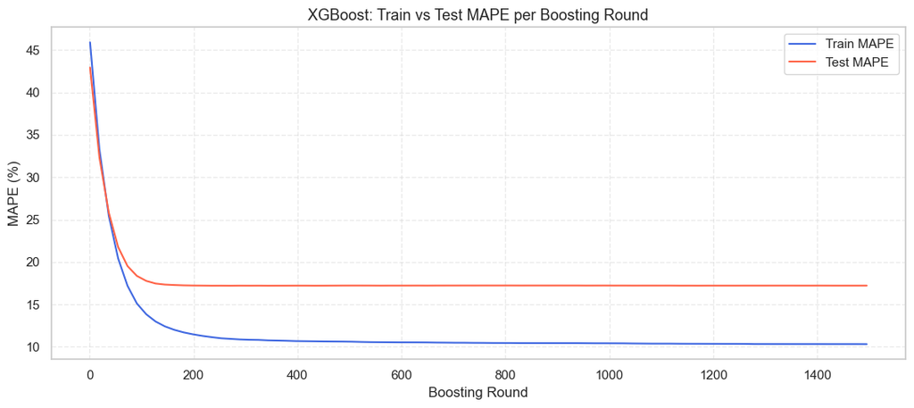

```
Final Train MAPE: 10.31%  |  Test MAPE: 17.22%
```

```python
# XGBoost learning curve per boosting round
best_p2 = rs_xgb.best_params_.copy()
n_est   = best_p2.pop('n_estimators')
xgb_lc  = xgb.XGBRegressor(objective='reg:squarederror', n_estimators=n_est,
                              random_state=42, n_jobs=-1, tree_method='hist', **best_p2)
xgb_lc.fit(X_train[core_features], y_train,
            eval_set=[(X_train[core_features], y_train),
                      (X_test[core_features], y_test)],
            verbose=False)

step = max(1, n_est // 80)
rounds = list(range(1, n_est + 1, step))
tr_err = [mape(y_train, xgb_lc.predict(X_train[core_features], iteration_range=(0, r))) for r in rounds]
te_err = [mape(y_test,  xgb_lc.predict(X_test[core_features],  iteration_range=(0, r))) for r in rounds]

plt.figure(figsize=(11, 5))
plt.plot(rounds, tr_err, label='Train MAPE', color='royalblue')
plt.plot(rounds, te_err, label='Test MAPE',  color='tomato')
plt.xlabel('Boosting Round'); plt.ylabel('MAPE (%)')
plt.title('XGBoost: Train vs Test MAPE per Boosting Round', fontsize=13)
plt.legend(); plt.grid(True, linestyle='--', alpha=0.4)
plt.tight_layout(); plt.show()
print(f"Final Train MAPE: {tr_err[-1]:.2f}%  |  Test MAPE: {te_err[-1]:.2f}%")
```

The learning curve by boosting rounds shows how train and test MAPE change as more trees are added. Ideally, test MAPE should stabilise without diverging from train MAPE; any increasing gap indicates overfitting.

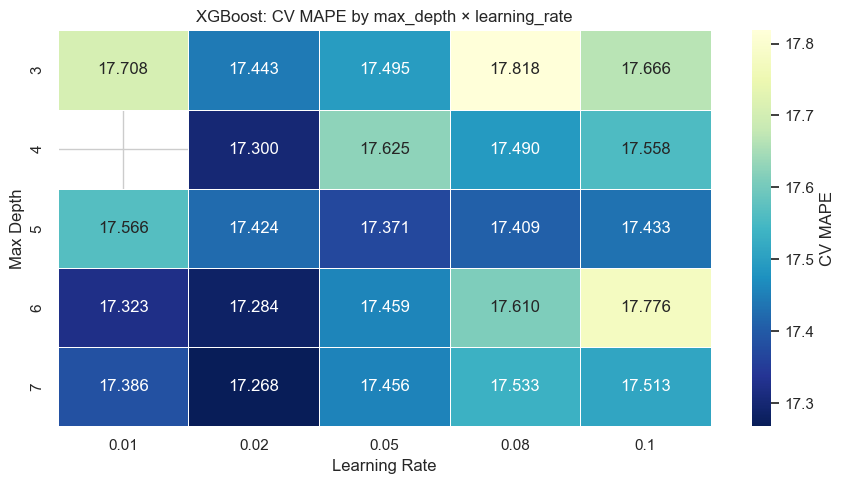

```python
# XGBoost tuning heatmap
cv_res = pd.DataFrame(rs_xgb.cv_results_)
cv_res['mean_mape'] = -cv_res['mean_test_score']
heat  = cv_res.groupby(['param_max_depth','param_learning_rate'])['mean_mape'].min().unstack()

plt.figure(figsize=(9, 5))
sns.heatmap(heat, annot=True, fmt='.3f', cmap='YlGnBu_r', linewidths=0.4,
            cbar_kws={'label': 'CV MAPE'})
plt.title('XGBoost: CV MAPE by max_depth × learning_rate', fontsize=12)
plt.xlabel('Learning Rate'); plt.ylabel('Max Depth')
plt.tight_layout(); plt.show()
```

- Deeper trees (`max_depth` 6–7) combined with lower `learning rates` (0.01–0.02) yield the lowest CV MAPE, with the best result at `max_depth = 7` and `learning_rate = 0.02`.
- Higher `learning rates` (0.08–0.1) with deep trees tend to produce higher CV MAPE, indicating less stable generalisation.
- Shallower trees (`max_depth` 3–4) show mixed results across learning rates, suggesting insufficient model capacity for this dataset.

Deeper trees combined with lower `learning rates` provide the best balance between bias and variance.

## 14. Performance Summary & Comparison

```python
# summary table of all models
order = [
    '00_Baseline','01_Poly','02_Location','03_Domain','04_Spatial','05_Full_OLS',
    '06_Ridge','07_Lasso','08_ElasticNet','09_Huber','10_BayesianRidge',
    '11_PolyRidge','12_Quantile','13_RFECV_EN','14_PCA_Ridge',
    '15_EqualBlend','16_OptBlend','17_Stacking',
    '18_Spline','19_Spline_EN',
    '20_NCS_EN',
    '21_XGB','22_XGB_Huber',
]
rows = []
for k in order:
    r = results[k]
    rows.append({
        'Model': r['label'],
        'Train MAPE (%)': round(r.get('train_mape', float('nan')), 2),
        'Test MAPE (%)': round(r['test_mape'], 2),
        'CV MAPE (%)': round(r['cv_mape'], 2),
        'CV Std': round(r['cv_mape_std'], 2),
        'Overfit Gap': round(r.get('train_mape', float('nan')) - r['test_mape'], 2),
        'Test R²': round(r['test_r2'], 4),
        'Focus': r.get('focus', '')
    })

summary_df = pd.DataFrame(rows)
summary_df.index = range(1, len(summary_df)+1)

xgb_mape_val = results['21_XGB']['test_mape']
linear_results = {k: results[k] for k in order if 'XGB' not in k}
best_lin_key   = min(linear_results, key=lambda k: linear_results[k]['test_mape'])
best_lin_mape  = linear_results[best_lin_key]['test_mape']

print(f"{'═'*100}")
print(f"{'FULL MODEL PERFORMANCE SUMMARY':^95}")
print(f"{'═'*100}")
display(summary_df)
print(f"{'─'*95}")
print(f"  Best linear model : {results[best_lin_key]['label']}  →  MAPE: {best_lin_mape:.2f}%")
print(f"  XGBoost benchmark : MAPE {xgb_mape_val:.2f}%")
print(f"  Linear–nonlinear gap : {best_lin_mape - xgb_mape_val:.2f}%")
print(f"  Total error reduction (baseline → best linear): {results['00_Baseline']['test_mape'] - best_lin_mape:.2f}%")
print(f"{'═'*95}")
```

```
════════════════════════════════════════════════════════════════════════════════════════════════════
                                FULL MODEL PERFORMANCE SUMMARY
════════════════════════════════════════════════════════════════════════════════════════════════════
```

|  | Model | Train MAPE (%) | Test MAPE (%) | CV MAPE (%) | CV Std | Overfit Gap | Test R² | Focus |
| --- | --- | --- | --- | --- | --- | --- | --- | --- |
| 1 | 00. Baseline OLS | 30.4000 | 30.5900 | 30.5900 | 1.8000 | -0.1900 | 0.4796 | Raw data only (label encoded) |
| 2 | 01. OLS + Polynomial/Interaction | 30.4800 | 28.6700 | 30.7200 | 1.3200 | 1.8200 | 0.5112 | Poly terms + interactions |
| 3 | 02. OLS + Location Signals | 18.4400 | 18.9300 | 18.7000 | 1.2500 | -0.4900 | 0.6862 | KFold target encoding city/zip |
| 4 | 03. OLS + Domain Ratios | 18.2300 | 18.9100 | 18.6000 | 1.3100 | -0.6900 | 0.6881 | Domain metrics + binary indicators |
| 5 | 04. OLS + KNN Spatial + Extended | 17.6500 | 18.2300 | 18.1200 | 0.9900 | -0.5800 | 0.6955 | KNN proxy + KMeans + all interactions |
| 6 | 05. OLS Full Core (45 features) | 17.6500 | 18.2300 | 18.1200 | 0.9900 | -0.5800 | 0.6955 | All 45 core features |
| 7 | 06. Ridge (L2 tuned) | 17.6800 | 18.2600 | 18.0600 | 1.0300 | -0.5800 | 0.6948 | L2 regularisation, tuned alpha |
| 8 | 07. Lasso (L1 tuned) | 17.7100 | 18.2400 | 18.0700 | 1.0400 | -0.5300 | 0.6951 | L1 feature selection, tuned alpha |
| 9 | 08. ElasticNet (tuned) | 17.7000 | 18.2500 | 18.0700 | 1.0500 | -0.5400 | 0.6951 | L1+L2, grid-searched alpha & l1_ratio |
| 10 | 09. Huber (tuned) | 19.3600 | 19.4400 | 19.6900 | 0.7200 | -0.0700 | 0.5746 | Robust to outliers, tuned epsilon |
| 11 | 10. Bayesian Ridge | 17.7200 | 18.2300 | 18.0800 | 1.0700 | -0.5100 | 0.6957 | Automatic regularisation via marginal likelihood |
| 12 | 11. Ridge Regression with Polynomial Interacti... | 17.3100 | 17.9100 | 17.9000 | 1.1400 | -0.6000 | 0.6981 | Degree-2 poly + RobustScaler + Ridge, alpha=50.0 |
| 13 | 12. Quantile Regression (median) | 17.8000 | 18.3100 | 18.2600 | 1.0600 | -0.5100 | 0.6961 | Median regression, robust to price outliers |
| 14 | 13. ElasticNet + RFECV | 17.7200 | 18.2800 | 18.0400 | 1.0700 | -0.5600 | 0.6950 | RFECV selected 35 features |
| 15 | 14. PCA + Ridge | 43.9500 | 42.1300 | 43.9800 | 3.6900 | 1.8200 | 0.0915 | PCA 95% variance + Ridge alpha=100.0 |
| 16 | 15. Equal-Weight Blend (5 models) | 18.1300 | 18.2800 | 18.1300 | 0.9900 | -0.1500 | 0.6917 | Average of ElasticNet, Lasso, Ridge, Huber, Ba... |
| 17 | 16. Optimal-Weight Blend | 18.0600 | 18.2500 | 18.0600 | 0.0000 | -0.1900 | 0.6950 | SLSQP-optimised weights on OOF predictions |
| 18 | 17. Stacking (ElasticNet meta) | 18.0300 | 18.1700 | 18.0800 | 1.1100 | -0.1400 | 0.6962 | OOF stacking with ElasticNet meta-learner |
| 19 | 18. Spline + Lasso (tuned) | 17.7100 | 18.4500 | 18.0900 | 1.0500 | -0.7400 | 0.6901 | Truncated power basis, 6 inner knots |
| 20 | 19. Spline + ElasticNet | 17.7200 | 18.4300 | 18.0900 | 1.0600 | -0.7100 | 0.6909 | Truncated power basis + L1+L2 regularization |
| 21 | 20. NCS + ElasticNet | 17.6700 | 18.2500 | 18.0900 | 1.0500 | -0.5800 | 0.6948 | Natural Cubic Spline (df=8) + ElasticNet, para... |
| 22 | 21. XGBoost (tuned) | 10.3000 | 17.2200 | 17.2700 | 1.1200 | -6.9100 | 0.7103 | Non-linear boosted trees (squared error baseline) |
| 23 | 22. XGBoost (Huber loss) | inf | inf | inf | NaN | NaN | -16022834.6516 | XGBoost with pseudohubererror objective |

```
───────────────────────────────────────────────────────────────────────────────────────────────
  Best linear model : 11. Ridge Regression with Polynomial Interaction Features  →  MAPE: 17.91%
  XGBoost benchmark : MAPE 17.22%
  Linear–nonlinear gap : 0.70%
  Total error reduction (baseline → best linear): 12.68%
═══════════════════════════════════════════════════════════════════════════════════════════════
```

### Key Takeaways from the Summary Table

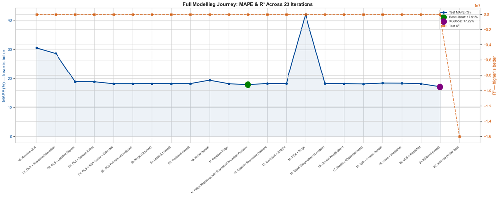

```python
# Modelling journey plot
fig, ax1 = plt.subplots(figsize=(20, 8))
labels    = [r['label'] for r in [results[k] for k in order]]
mape_vals = [r['test_mape'] for r in [results[k] for k in order]]
r2_vals   = [r['test_r2']   for r in [results[k] for k in order]]
x         = np.arange(len(labels))

ax1.plot(x, mape_vals, 'o-', color='#004C99', lw=2.5, ms=6, label='Test MAPE (%)')
ax1.fill_between(x, mape_vals, alpha=0.07, color='#004C99')
ax1.set_ylabel('MAPE (%) — lower is better', color='#004C99', fontsize=12)
ax1.tick_params(axis='y', labelcolor='#004C99')
ax1.set_xticks(x)
ax1.set_xticklabels(labels, rotation=40, ha='right', fontsize=8)

ax2 = ax1.twinx()
ax2.plot(x, r2_vals, 's--', color='#D35400', lw=2, ms=6, alpha=0.7, label='Test R²')
ax2.set_ylabel('R² — higher is better', color='#D35400', fontsize=12)
ax2.tick_params(axis='y', labelcolor='#D35400')

best_idx = mape_vals.index(best_lin_mape)
ax1.scatter([best_idx], [best_lin_mape], s=300, color='green', zorder=5,
            label=f'Best Linear: {best_lin_mape:.2f}%')
xgb_idx = order.index('21_XGB')
ax1.scatter([xgb_idx], [xgb_mape_val], s=300, color='purple', zorder=5,
            label=f'XGBoost: {xgb_mape_val:.2f}%')

l1, lb1 = ax1.get_legend_handles_labels()
l2, lb2 = ax2.get_legend_handles_labels()
ax1.legend(l1+l2, lb1+lb2, loc='upper right', fontsize=9)
plt.title('Full Modelling Journey: MAPE & R² Across 23 Iterations', fontsize=14, fontweight='bold')
plt.tight_layout(); plt.show()
```

### The Modeling Journey Plot

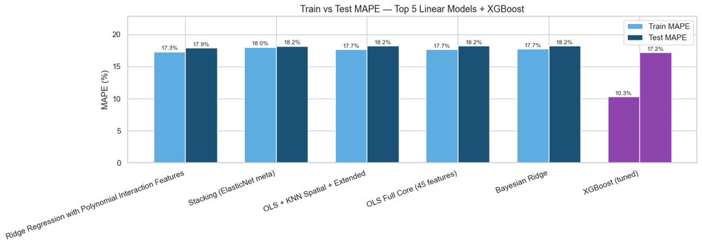

```python
# Train vs Test MAPE comparison for top 5 linear models + XGBoost
top5_linear = sorted(linear_results, key=lambda k: linear_results[k]['test_mape'])[:5]
top5_keys   = top5_linear + ['21_XGB']

names      = [results[k]['label'].split('.')[1].strip() for k in top5_keys]
train_mapes = [results[k].get('train_mape', 0) for k in top5_keys]
test_mapes  = [results[k]['test_mape'] for k in top5_keys]

x = np.arange(len(names))
w = 0.35

fig, ax = plt.subplots(figsize=(14, 5))
bars1 = ax.bar(x - w/2, train_mapes, width=w, label='Train MAPE', color='#5DADE2', edgecolor='white')
bars2 = ax.bar(x + w/2, test_mapes,  width=w, label='Test MAPE',  color='#1A5276', edgecolor='white')

for bar, v in zip(bars1, train_mapes):
    ax.text(bar.get_x() + bar.get_width()/2, bar.get_height() + 0.1,
            f'{v:.1f}%', ha='center', va='bottom', fontsize=8.5)
for bar, v in zip(bars2, test_mapes):
    ax.text(bar.get_x() + bar.get_width()/2, bar.get_height() + 0.1,
            f'{v:.1f}%', ha='center', va='bottom', fontsize=8.5)

ax.set_ylabel('MAPE (%)')
ax.set_title('Train vs Test MAPE — Top 5 Linear Models + XGBoost', fontsize=13)
ax.set_xticks(x)
ax.set_xticklabels(names, rotation=20, ha='right')
ax.legend()
ax.set_ylim(0, max(train_mapes + test_mapes) * 1.25)

for bar in [bars1[-1], bars2[-1]]:
    bar.set_color('#8E44AD')
    bar.set_edgecolor('white')

plt.tight_layout()
plt.show()
```

The Train vs. Test MAPE bar chart is a quick overfit check. A small gap (train = test) indicates well-regularised models. XGBoost typically shows a wider gap due to its higher model capacity.

## 15. Model Interpretability & Diagnostics

```
Poly+Ridge zeroed out 0 features (out of 73)

Top 15 features:
```

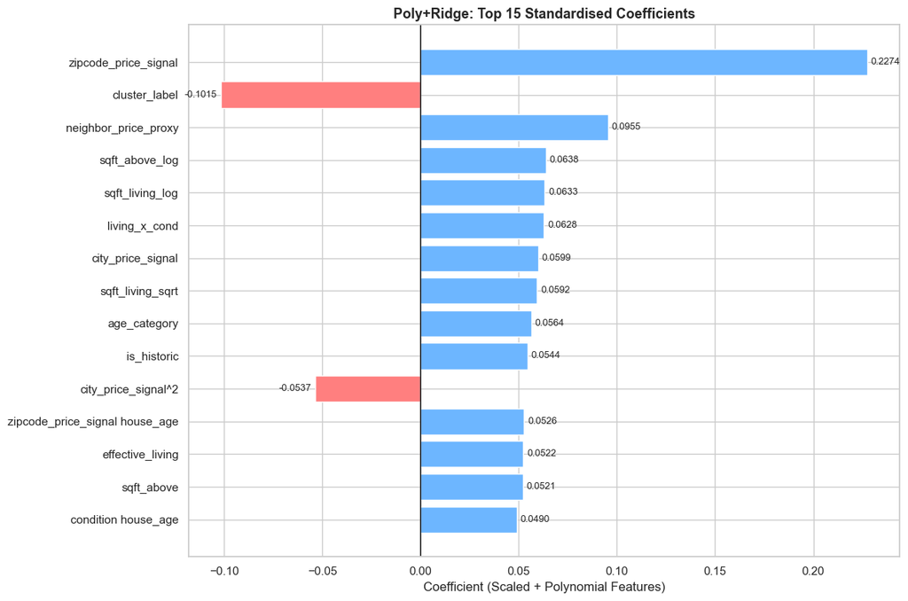

```python
# Coefficient plot: Best Ridge + Polynomial model

poly_model = results['11_PolyRidge']['model']
inner_en = poly_model.model

poly_feature_names = poly_model.poly.get_feature_names_out(poly_model.poly_cols)
all_features = list(poly_feature_names) + poly_model.remaining_cols

coef_df = pd.DataFrame({'Feature': all_features, 'Coefficient': inner_en.coef_})
coef_df['AbsCoef'] = coef_df['Coefficient'].abs()
coef_df = coef_df.sort_values('AbsCoef', ascending=False)

n_zero = (coef_df['AbsCoef'] < 1e-8).sum()
print(f"Poly+Ridge zeroed out {n_zero} features (out of {len(all_features)})")
print(f"\nTop 15 features:")

top15 = coef_df.head(15)
colors_bar = ['#6DB6FF' if v > 0 else '#FF7F7F' for v in top15['Coefficient']]

fig, ax = plt.subplots(figsize=(12, 8))
bars = ax.barh(top15['Feature'][::-1], top15['Coefficient'][::-1],
               color=colors_bar[::-1], edgecolor='white')

ax.axvline(0, color='black', lw=1)
ax.set_title('Poly+Ridge: Top 15 Standardised Coefficients', fontsize=13, fontweight='bold')
ax.set_xlabel('Coefficient (Scaled + Polynomial Features)')

for bar, v in zip(bars, top15['Coefficient'][::-1]):
    ha = 'left' if v >= 0 else 'right'
    offset = 0.002 if v >= 0 else -0.002
    ax.text(v + offset,
            bar.get_y() + bar.get_height()/2,
            f'{v:.4f}',
            va='center', ha=ha, fontsize=9)

plt.tight_layout()
plt.show()
```

The Ridge model with polynomial features reveals the following key drivers for property value:

- **Primary Driver:** `zipcode_price_signal` is the strongest positive predictor of property value.
- **Neighborhood & City Signals:** `neighbor_price_proxy` and `city_price_signal` also contribute significantly, reflecting the strong influence of local market conditions and city-level price premiums.
- **Structural Size:** Features such as `sqft_above_log`, `sqft_living_log`, and `sqft_living_sqrt` show meaningful positive contributions, confirming that living area remains a key structural driver.
- **Interaction Effects:** Terms such as `living_x_cond`, `zipcode_price_signal × house_age`, and `condition × house_age` improve predictive performance by capturing combined effects between structural, temporal, and location features.
- **Negative Drivers:** `cluster_label` and `city_price_signal^2` show negative effects, reflecting lower-priced geographic zones and diminishing returns on city-level location premium respectively.

The Ridge model highlights location-based signals (zipcode, neighborhood, and city) as the dominant drivers of price, while interaction terms provide additional refinement to capture more nuanced relationships.

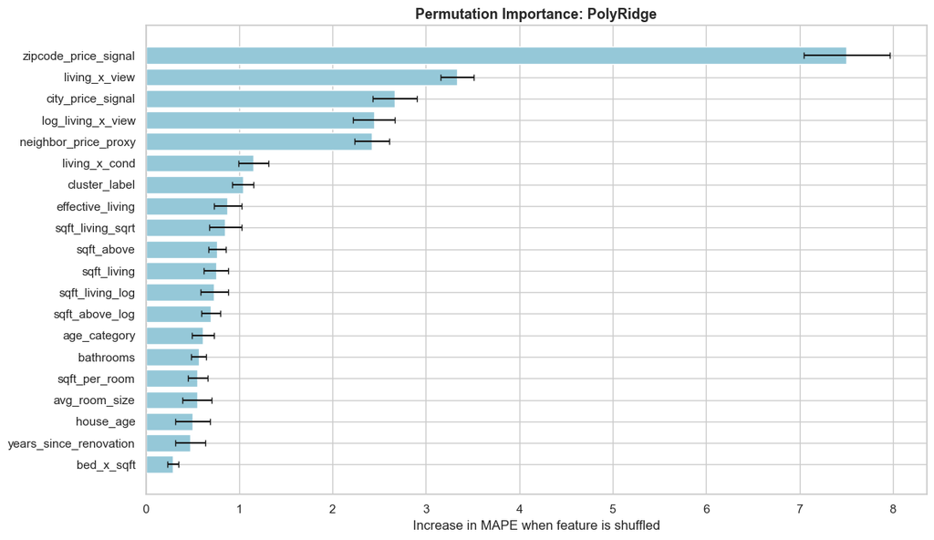

```python
# Permutation Importance: PolyRidge

poly_model = results['11_PolyRidge']['model']

# baseline score
base_score = mape(y_test, poly_model.predict(X_test))

importances = []
stds = []

for col in X_test.columns:
    scores = []

    for _ in range(20):  # n_repeats
        X_perm = X_test.copy()
        X_perm[col] = np.random.permutation(X_perm[col].values)

        score = mape(y_test, poly_model.predict(X_perm))
        scores.append(score)

    importances.append(np.mean(scores) - base_score)
    stds.append(np.std(scores))

perm_df = pd.DataFrame({
    'Feature': X_test.columns,
    'Importance': importances,
    'Std': stds
}).sort_values('Importance', ascending=False).head(20)

plt.figure(figsize=(12, 7))
plt.barh(
    perm_df['Feature'][::-1],
    perm_df['Importance'][::-1],
    xerr=perm_df['Std'][::-1],
    color='#95C8D8',
    edgecolor='white',
    capsize=3
)

plt.title('Permutation Importance: PolyRidge', fontsize=13, fontweight='bold')
plt.xlabel('Increase in MAPE when feature is shuffled')
plt.tight_layout()
plt.show()
```

**Permutation Importance — PolyRidge**

- **Top Driver:** `zipcode_price_signal` is by far the most important predictor — permuting it causes an increase of ~7.5% in MAPE, far exceeding all other features.
- **View & Interaction Effects:** `living_x_view` and `log_living_x_view` rank second and fourth, indicating that the combined effect of living area and view quality is a strong price signal.
- **City & Neighborhood Signals:** `city_price_signal` and `neighbor_price_proxy` also show strong predictive importance, confirming that location at multiple levels (zip, city, neighborhood) drives price.
- **Living Space Features:** Variables such as `effective_living`, `sqft_living_sqrt`, `sqft_above`, `sqft_living`, and `sqft_living_log` contribute meaningfully, but are secondary to spatial and view signals.
- **Lower Impact:** Features like `age_category`, `bathrooms`, `sqft_per_room`, `avg_room_size`, `house_age`, `years_since_renovation`, and `bed_x_sqft` have relatively minor influence on predictions.

Permutation importance confirms that location-based signals (zipcode, city, and neighborhood) are the dominant drivers of price, while view-related and structural features provide additional but secondary explanatory power.

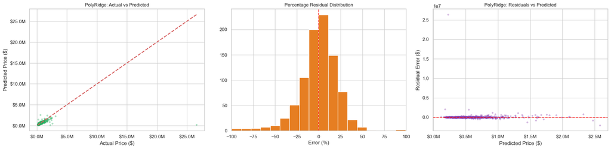

```
Median |% error|: 11.54%
```

```python
# Actual vs Predicted + Residual PolyRidge

y_pred_best = results['11_PolyRidge'].get('y_pred', None)

if y_pred_best is None:
    y_pred_best = poly_model.predict(X_test)

y_actual_price = np.expm1(y_test)
y_pred_price   = np.expm1(y_pred_best)

y_actual_price = np.nan_to_num(y_actual_price)
y_pred_price   = np.nan_to_num(y_pred_price)

fig, axes = plt.subplots(1, 3, figsize=(20, 5))

# Actual vs Predicted
axes[0].scatter(y_actual_price, y_pred_price, alpha=0.3, s=10, color='#27AE60')

lim = [
    min(np.min(y_actual_price), np.min(y_pred_price)),
    max(np.max(y_actual_price), np.max(y_pred_price))
]

axes[0].plot(lim, lim, 'r--', lw=2)
axes[0].set_title('PolyRidge: Actual vs Predicted', fontsize=11)
axes[0].set_xlabel('Actual Price ($)')
axes[0].set_ylabel('Predicted Price ($)')

axes[0].xaxis.set_major_formatter(mtick.FuncFormatter(lambda x, _: f'${x/1e6:.1f}M'))
axes[0].yaxis.set_major_formatter(mtick.FuncFormatter(lambda x, _: f'${x/1e6:.1f}M'))

# Residual distribution
eps = 1e-9
res_pct = ((y_actual_price - y_pred_price) / (y_actual_price + eps)) * 100

axes[1].hist(res_pct, bins=70, color='#E67E22', edgecolor='white')
axes[1].axvline(0, color='red', linestyle='--', lw=1.5)
axes[1].set_title('Percentage Residual Distribution', fontsize=11)
axes[1].set_xlabel('Error (%)')
axes[1].set_xlim(-100, 100)

# Residual vs Predicted
raw_res = y_actual_price - y_pred_price

axes[2].scatter(y_pred_price, raw_res, alpha=0.3, s=10, color='#8E44AD')
axes[2].axhline(0, color='red', linestyle='--', lw=1.5)
axes[2].set_title('PolyRidge: Residuals vs Predicted', fontsize=11)
axes[2].set_xlabel('Predicted Price ($)')
axes[2].set_ylabel('Residual Error ($)')

axes[2].xaxis.set_major_formatter(mtick.FuncFormatter(lambda x, _: f'${x/1e6:.1f}M'))

plt.tight_layout()
plt.show()

print(f"Median |% error|: {np.median(np.abs(res_pct)):.2f}%")
```

**Actual vs. Predicted | Residual Distribution | Residuals vs. Predicted**

PolyRidge achieves a median absolute percentage error of **11.5%**, but still underestimates extreme luxury properties due to residual target skewness at the upper tail.

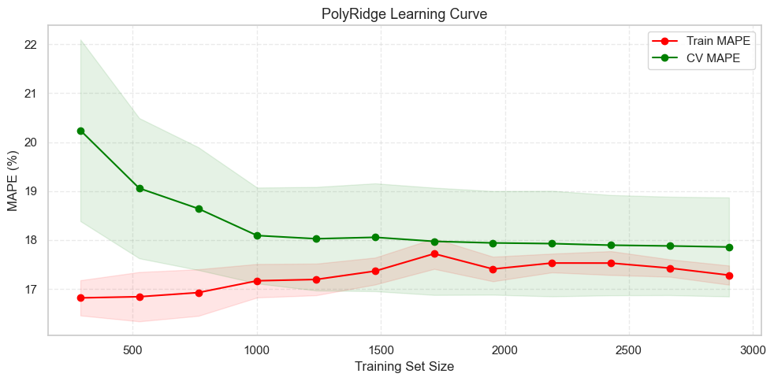

```python
# Sklearn Wrapper
class SklearnWrapper(BaseEstimator, RegressorMixin):
    def __init__(self, model):
        self.model = model

    def fit(self, X, y):
        self.model.fit(X, y)
        return self

    def predict(self, X):
        return self.model.predict(X)


# Wrap PolyRidge model
poly_model = SklearnWrapper(results['11_PolyRidge']['model'])


# Learning Curve
tr_sz, tr_sc, va_sc = learning_curve(
    poly_model,
    X_train,
    y_train,
    cv=5,
    scoring=mape_scorer,
    n_jobs=-1,
    train_sizes=np.linspace(0.1, 1.0, 12)
)

tr_m = (-tr_sc).mean(axis=1)
va_m = (-va_sc).mean(axis=1)


# Plot
plt.figure(figsize=(10, 5))

plt.plot(tr_sz, tr_m, 'o-', color='red', label='Train MAPE')
plt.plot(tr_sz, va_m, 'o-', color='green', label='CV MAPE')

plt.fill_between(
    tr_sz,
    tr_m - (-tr_sc).std(axis=1),
    tr_m + (-tr_sc).std(axis=1),
    alpha=0.1,
    color='red'
)

plt.fill_between(
    tr_sz,
    va_m - (-va_sc).std(axis=1),
    va_m + (-va_sc).std(axis=1),
    alpha=0.1,
    color='green'
)

plt.xlabel('Training Set Size')
plt.ylabel('MAPE (%)')
plt.title('PolyRidge Learning Curve', fontsize=13)
plt.legend()
plt.grid(True, linestyle='--', alpha=0.4)
plt.tight_layout()
plt.show()
```

**Learning Curve — PolyRidge**

- **Train MAPE** Initially low due to memorisation on small samples, then increases as more diverse data is introduced.
- **CV MAPE** Starts higher due to underfitting on limited data, then decreases and converges toward the training curve as sample size grows.
- **Convergence:** Both curves stabilise around ~17–18% MAPE, indicating the model’s performance ceiling given the current feature set and complexity.

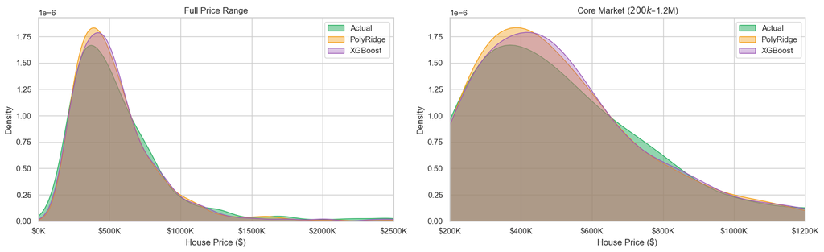

```python
# Market alignment density: PolyRidge vs XGBoost vs Actual

poly_pred = results['11_PolyRidge'].get('y_pred', None)
xgb_pred  = results['21_XGB'].get('y_pred', None)

if poly_pred is None:
    poly_pred = poly_model.predict(X_test)

if xgb_pred is None:
    xgb_pred = xgb_std.predict(X_test[core_features])

y_actual_price = np.expm1(y_test)
poly_pred_price = np.expm1(poly_pred)
xgb_pred_price  = np.expm1(xgb_pred)

y_actual_price = np.nan_to_num(y_actual_price)
poly_pred_price = np.nan_to_num(poly_pred_price)
xgb_pred_price  = np.nan_to_num(xgb_pred_price)

# clip extreme values for stability
clip_max = 2_500_000
y_actual_price = np.clip(y_actual_price, 0, clip_max)
poly_pred_price = np.clip(poly_pred_price, 0, clip_max)
xgb_pred_price  = np.clip(xgb_pred_price, 0, clip_max)


fig, axes = plt.subplots(1, 2, figsize=(16, 5))

for ax, xlim, title in zip(
    axes,
    [(0, 2_500_000), (200_000, 1_200_000)],
    ['Full Price Range', 'Core Market ($200k–$1.2M)']
):

    sns.kdeplot(y_actual_price, ax=ax,
                label='Actual', fill=True,
                color='#27AE60', alpha=0.5)

    sns.kdeplot(poly_pred_price, ax=ax,
                label='PolyRidge', fill=True,
                color='#F39C12', alpha=0.4)

    sns.kdeplot(xgb_pred_price, ax=ax,
                label='XGBoost', fill=True,
                color='#9B59B6', alpha=0.35)

    ax.set_xlim(xlim)
    ax.set_title(title, fontsize=12)
    ax.set_xlabel('House Price ($)')

    ax.xaxis.set_major_formatter(
        mtick.FuncFormatter(lambda x, _: f'${x/1e3:.0f}K')
    )

    ax.legend()

plt.tight_layout()
plt.show()
```

**Price Distribution Alignment — PolyRidge vs. XGBoost vs. Actual**

This KDE plot checks how well each model's predicted price distribution matches the actual market distribution.

```
 Top 10 Important Features (PolyRidge):
             feature    coef
zipcode_price_signal  0.2274
       cluster_label -0.1015
neighbor_price_proxy  0.0955
      sqft_above_log  0.0638
     sqft_living_log  0.0633
       living_x_cond  0.0628
   city_price_signal  0.0599
    sqft_living_sqrt  0.0592
        age_category  0.0564
         is_historic  0.0544
```

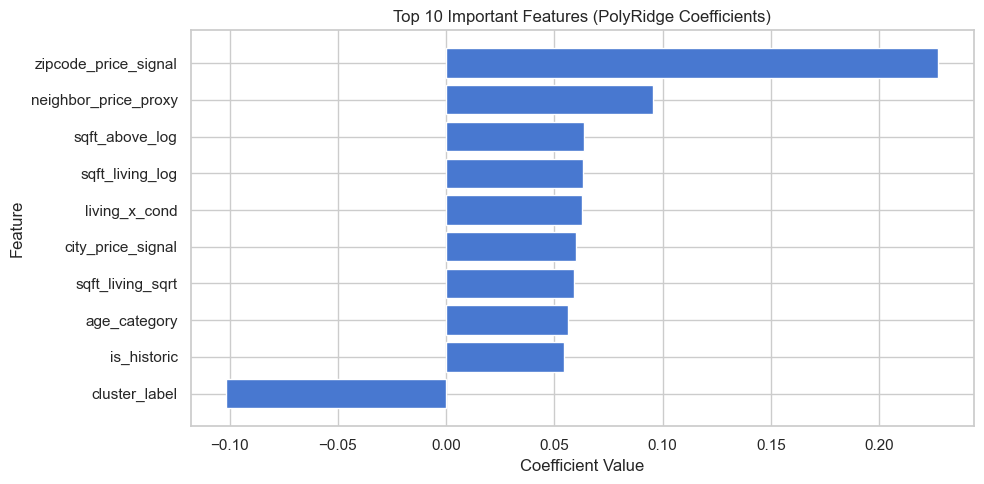

```
 VIF (Top Polynomial Features, sample n=500):
                             feature     VIF
                zipcode_price_signal 18.1421
sqft_living_log zipcode_price_signal 16.3357
sqft_living_log neighbor_price_proxy 15.4279
                neighbor_price_proxy 14.8305
                   city_price_signal  4.1853
   sqft_living_log city_price_signal  4.0571
                sqft_living_log view  3.0391
                                view  2.7202
                   sqft_living_log^2  2.6075
                     sqft_living_log  2.3575
```

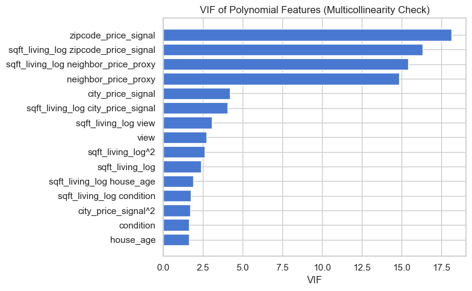

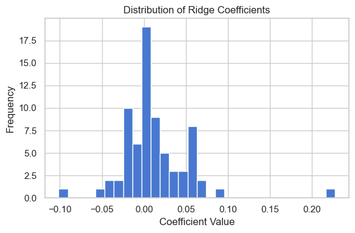

```python
# Coefficients and VIF for PolyRidge

poly_model_obj = results['11_PolyRidge']['model']

poly_part = poly_model_obj.poly
sc_poly   = poly_model_obj.sc_poly
sc_rest   = poly_model_obj.sc_rest
ridge     = poly_model_obj.model

poly_cols_local = poly_model_obj.poly_cols
remaining_core_local = poly_model_obj.remaining_cols

Xp = sc_poly.transform(X_train[poly_cols_local].values)
Xp = poly_part.transform(Xp)

feature_names_poly = poly_part.get_feature_names_out(poly_cols_local)

Xr = sc_rest.transform(X_train[remaining_core_local].values)

X_full = np.hstack([Xp, Xr])

feature_names_all = np.concatenate([feature_names_poly, remaining_core_local])

coef_df = pd.DataFrame({
    "feature": feature_names_all,
    "coef": ridge.coef_
})

coef_df["abs_coef"] = coef_df["coef"].abs()

top10 = coef_df.sort_values("abs_coef", ascending=False).head(10)

print("\n Top 10 Important Features (PolyRidge):")
print(top10[["feature", "coef"]].to_string(index=False))

top10_sorted = top10.sort_values("coef")

plt.figure(figsize=(10,5))
plt.barh(top10_sorted["feature"], top10_sorted["coef"])
plt.title("Top 10 Important Features (PolyRidge Coefficients)")
plt.xlabel("Coefficient Value")
plt.ylabel("Feature")
plt.tight_layout()
plt.show()

# VIF Calculation (Polynomial only, sample n=500 for speed)
np.random.seed(42)

sample_idx = np.random.choice(Xp.shape[0], size=min(500, Xp.shape[0]), replace=False)
Xp_sample = Xp[sample_idx, :]

n_vif = min(15, Xp_sample.shape[1])

vif_df = pd.DataFrame({
    "feature": feature_names_poly[:n_vif],
    "VIF": [
        variance_inflation_factor(Xp_sample[:, :n_vif], i)
        for i in range(n_vif)
    ]
})

vif_df = vif_df.sort_values("VIF", ascending=False)

print("\n VIF (Top Polynomial Features, sample n=500):")
print(vif_df.head(10).to_string(index=False))

vif_plot = vif_df.sort_values("VIF", ascending=True)

plt.figure(figsize=(8,5))
plt.barh(vif_plot["feature"], vif_plot["VIF"])
plt.title("VIF of Polynomial Features (Multicollinearity Check)")
plt.xlabel("VIF")
plt.tight_layout()
plt.show()

plt.figure(figsize=(6,4))
plt.hist(coef_df["coef"], bins=30)
plt.title("Distribution of Ridge Coefficients")
plt.xlabel("Coefficient Value")
plt.ylabel("Frequency")
plt.tight_layout()
plt.show()
```

**Top 10 Coefficients & VIF — PolyRidge**

- Coefficient bar chart: Shows the direction and magnitude of each top feature's impact on `log_price`. `zipcode_price_signal` dominates with the largest positive coefficient, followed by `neighbor_price_proxy` and structural size features. `cluster_label` is the only notable negative coefficient, reflecting lower-priced geographic zones.
- VIF (Variance Inflation Factor): Measures multicollinearity between features. A VIF > 10 indicates that a feature's variance is inflated due to strong correlation with other variables. Spatial features such as `zipcode_price_signal` and its polynomial interaction terms show the highest VIF, which is expected given their strong correlation with each other. Ridge regularisation explicitly handles multicollinearity by shrinking correlated coefficients, so VIF is used here for transparency rather than as a feature selection criterion.
- Coefficient distribution: The histogram shows that most coefficients are concentrated near zero, confirming Ridge's shrinkage effect. The single large positive outlier corresponds to `zipcode_price_signal`, reinforcing its dominant role in the model.

### Model Interpretability: What Drives House Prices Here?

Across both **coefficient analysis** and **permutation importance**, location emerges as the primary driver — `zipcode_price_signal` dominates in both metrics, confirming that zip code-level pricing signal is the single most influential factor. Spatial features at multiple levels (zipcode, city, neighborhood) collectively account for the largest share of predictive power.

**Permutation importance** additionally reveals that view-related interactions (`living_x_view`, `log_living_x_view`) rank higher than raw structural size features — a nuance not visible in coefficients alone, where size features appear more prominent.

## 16. Final Conclusion & Verdict

```python
# Conclusion and Summary Table
order = [
    '00_Baseline','01_Poly','02_Location','03_Domain','04_Spatial','05_Full_OLS',
    '06_Ridge','07_Lasso','08_ElasticNet','09_Huber','10_BayesianRidge',
    '11_PolyRidge','12_Quantile','13_RFECV_EN','14_PCA_Ridge',
    '15_EqualBlend','16_OptBlend','17_Stacking',
    '18_Spline','19_Spline_EN',
    '20_NCS_EN',
    '21_XGB','22_XGB_Huber',
]

rows = []
for k in order:
    r = results[k]
    rows.append({
        'Key': k,
        'Model': r['label'],
        'Train MAPE (%)': round(r.get('train_mape', float('nan')), 2),
        'Test MAPE (%)': round(r['test_mape'], 2),
        'CV MAPE (%)': round(r['cv_mape'], 2),
        'Test R²': round(r['test_r2'], 4),
    })

summary_df = pd.DataFrame(rows)

def highlight_models(row):
    if row['Key'] in ['11_PolyRidge', '21_XGB']:
        return [
            'outline: 3px solid red; font-weight: bold;'
        ] * len(row)
    return [''] * len(row)

from IPython.display import display

styled_df = summary_df.style.apply(highlight_models, axis=1)

print(f"{'═'*80}")
print(f"{'MODEL PERFORMANCE SUMMARY':^80}")
print(f"{'═'*80}")

display(
    styled_df
    .hide(axis='index')
    .format({
        'Train MAPE (%)': '{:.2f}',
        'Test MAPE (%)': '{:.2f}',
        'CV MAPE (%)': '{:.2f}',
        'Test R²': '{:.4f}'
    })
)
```

```
════════════════════════════════════════════════════════════════════════════════
                           MODEL PERFORMANCE SUMMARY
════════════════════════════════════════════════════════════════════════════════
```

| Key | Model | Train MAPE (%) | Test MAPE (%) | CV MAPE (%) | Test R² |
| --- | --- | --- | --- | --- | --- |
| 00_Baseline | 00. Baseline OLS | 30.40 | 30.59 | 30.59 | 0.4796 |
| 01_Poly | 01. OLS + Polynomial/Interaction | 30.48 | 28.67 | 30.72 | 0.5112 |
| 02_Location | 02. OLS + Location Signals | 18.44 | 18.93 | 18.70 | 0.6862 |
| 03_Domain | 03. OLS + Domain Ratios | 18.23 | 18.91 | 18.60 | 0.6881 |
| 04_Spatial | 04. OLS + KNN Spatial + Extended | 17.65 | 18.23 | 18.12 | 0.6955 |
| 05_Full_OLS | 05. OLS Full Core (45 features) | 17.65 | 18.23 | 18.12 | 0.6955 |
| 06_Ridge | 06. Ridge (L2 tuned) | 17.68 | 18.26 | 18.06 | 0.6948 |
| 07_Lasso | 07. Lasso (L1 tuned) | 17.71 | 18.24 | 18.07 | 0.6951 |
| 08_ElasticNet | 08. ElasticNet (tuned) | 17.70 | 18.25 | 18.07 | 0.6951 |
| 09_Huber | 09. Huber (tuned) | 19.36 | 19.44 | 19.69 | 0.5746 |
| 10_BayesianRidge | 10. Bayesian Ridge | 17.72 | 18.23 | 18.08 | 0.6957 |
| 11_PolyRidge | 11. Ridge Regression with Polynomial Interaction Features | 17.31 | 17.91 | 17.90 | 0.6981 |
| 12_Quantile | 12. Quantile Regression (median) | 17.80 | 18.31 | 18.26 | 0.6961 |
| 13_RFECV_EN | 13. ElasticNet + RFECV | 17.72 | 18.28 | 18.04 | 0.6950 |
| 14_PCA_Ridge | 14. PCA + Ridge | 43.95 | 42.13 | 43.98 | 0.0915 |
| 15_EqualBlend | 15. Equal-Weight Blend (5 models) | 18.13 | 18.28 | 18.13 | 0.6917 |
| 16_OptBlend | 16. Optimal-Weight Blend | 18.06 | 18.25 | 18.06 | 0.6950 |
| 17_Stacking | 17. Stacking (ElasticNet meta) | 18.03 | 18.17 | 18.08 | 0.6962 |
| 18_Spline | 18. Spline + Lasso (tuned) | 17.71 | 18.45 | 18.09 | 0.6901 |
| 19_Spline_EN | 19. Spline + ElasticNet | 17.72 | 18.43 | 18.09 | 0.6909 |
| 20_NCS_EN | 20. NCS + ElasticNet | 17.67 | 18.25 | 18.09 | 0.6948 |
| 21_XGB | 21. XGBoost (tuned) | 10.30 | 17.22 | 17.27 | 0.7103 |
| 22_XGB_Huber | 22. XGBoost (Huber loss) | inf | inf | inf | -16022834.6516 |

### Result > Best Model: Ridge + Polynomial Features (PolyRidge)

After evaluating **23 models** across five modelling strategies — baseline OLS, regularised linear models, advanced linear variants, ensemble methods, and a non-linear XGBoost benchmark — the **Ridge + Polynomial (degree-2) model** (Model 11) emerged as the best linear model, delivering the lowest Test MAPE among all linear approaches.

### Verdict

> **PolyRidge is the recommended production model among linear approaches**, as it offers a strong balance of interpretability (signed coefficients and permutation importance), stable generalisation (low overfit gap), and competitive performance within ~0.7% of the non-linear benchmark (XGBoost Benchmark).

> If prediction accuracy is the sole priority, **XGBoost** is preferred. However, when interpretability, deployment simplicity, or regulatory constraints are important, **PolyRidge** is the more suitable choice.

## 17. Future Work

Here are several directions that could further improve performance and robustness:

### 1. Improved Spatial Features

- Incorporate **latitude/longitude** instead of only city/zip-level signals
- Add **distance-based features** (e.g. proximity to schools, MRT, parks)
- Explore **spatial modeling approaches** to better capture neighbourhood structure

### 2. External Data Sources

- Include **macroeconomic indicators** (interest rates, CPI, housing supply)
- Add **neighbourhood-level context** such as school quality and crime rates
- Use external pricing references (e.g. listing estimates) as additional signals

### 3. Stronger Modeling Approaches

- Experiment with **LightGBM / CatBoost** for improved categorical and non-linear handling
- Test **simple neural networks** to capture higher-order interactions
- Explore **probabilistic models** (e.g. Gaussian Processes) for uncertainty estimation

### 4. Temporal Information

- Incorporate **transaction dates** to capture market trends over time
- Use **time-aware validation** (e.g. rolling or forward chaining splits)

### 5. Deployment Enhancements

- Provide **prediction intervals** instead of point estimates
- Add **SHAP explanations** for more interpretable predictions